# Abstract

### 3.4.3 Analysis on Energy dataset for low carbon sources

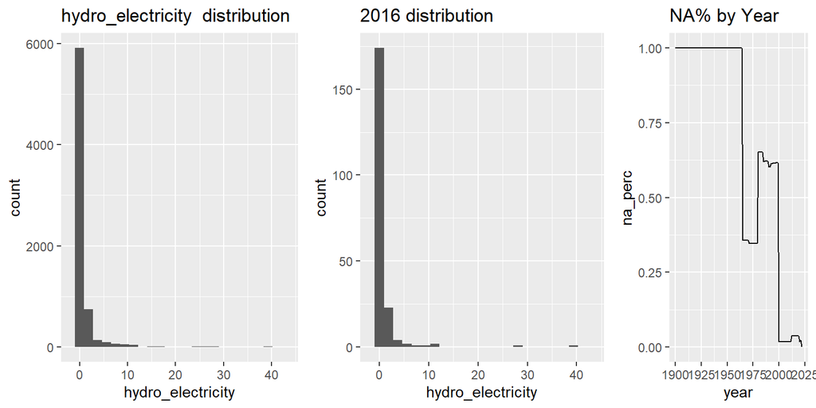

```
## [1] "Top three countries in 2016 for hydro_electricity : Iceland , Norway , Canada"
```

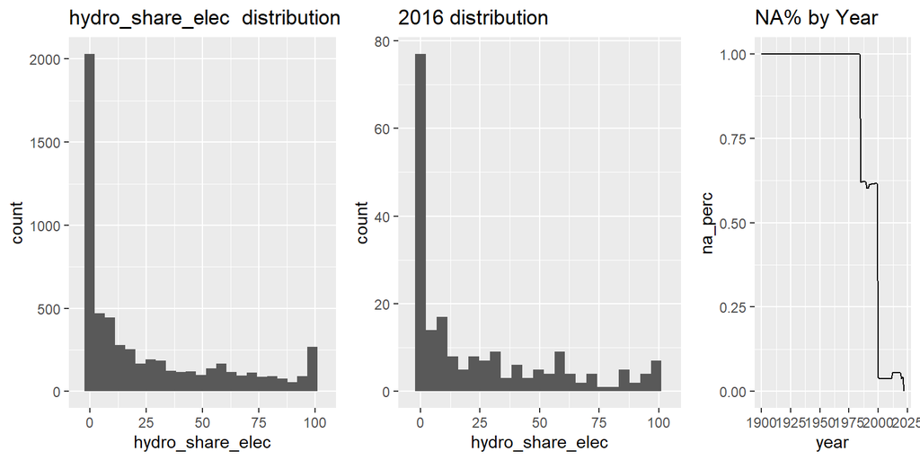

```
## [1] "Top three countries in 2016 for hydro_share_elec : Albania , Bhutan , Central African Republic"
```

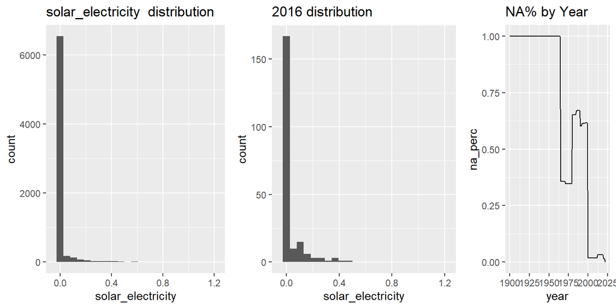

```
## [1] "Top three countries in 2016 for solar_electricity : Germany , Guam , Italy"
```

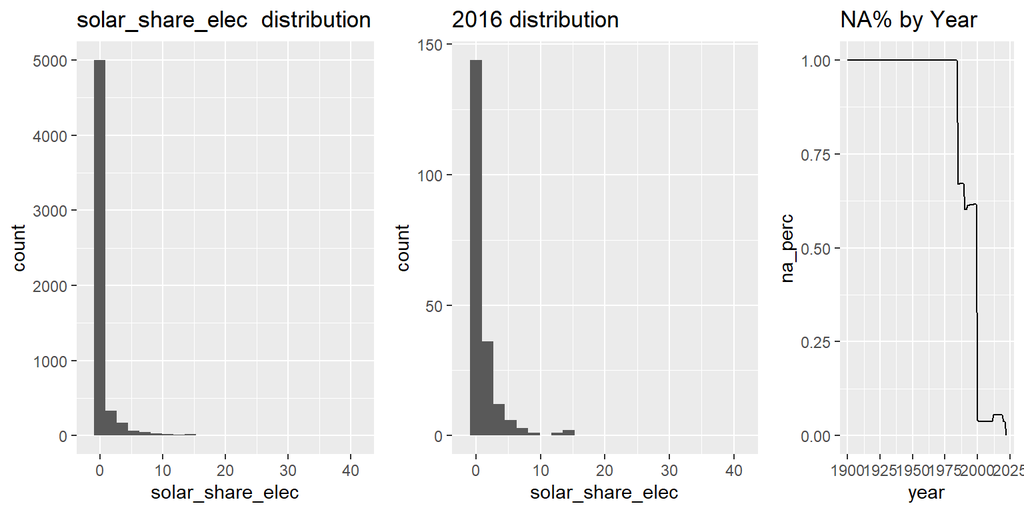

```
## [1] "Top three countries in 2016 for solar_share_elec : Malta , Samoa , Luxembourg"
```

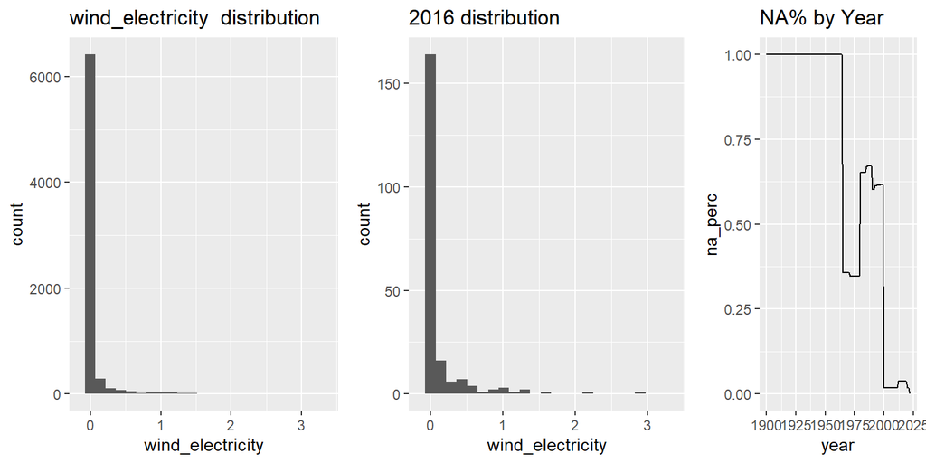

```
## [1] "Top three countries in 2016 for wind_electricity : Falkland Islands , Denmark , Sweden"
```

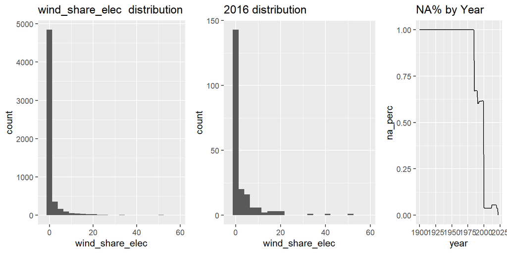

```
## [1] "Top three countries in 2016 for wind_share_elec : Falkland Islands , Denmark , Lithuania"
```

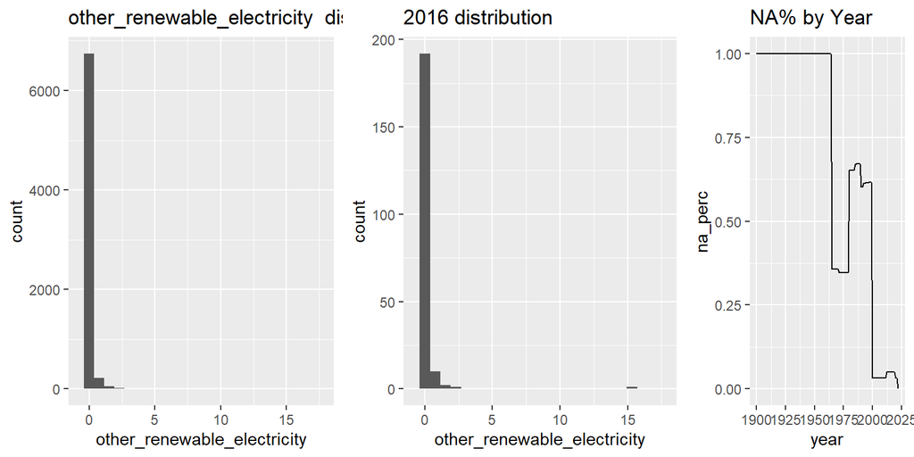

```
## [1] "Top three countries in 2016 for other_renewable_electricity : Iceland , Finland , New Zealand"
```

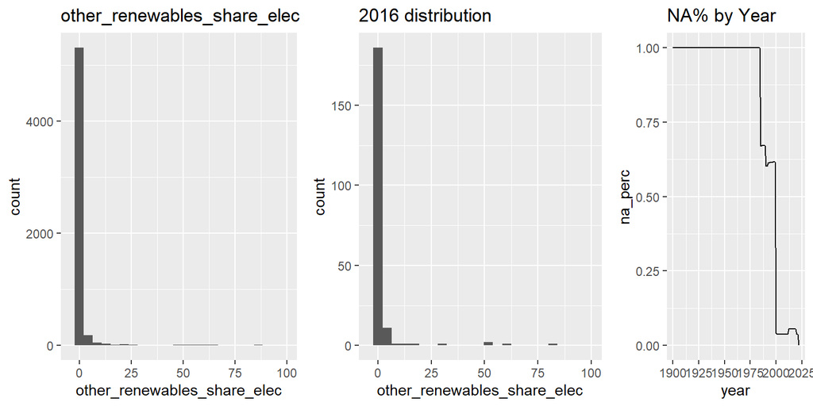

```
## [1] "Top three countries in 2016 for other_renewables_share_elec : Iceland , Eswatini , Belize"
```

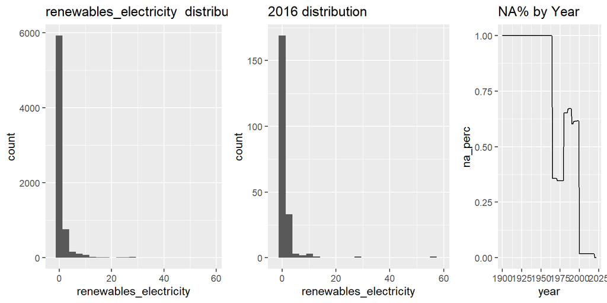

```
## [1] "Top three countries in 2016 for renewables_electricity : Iceland , Norway , Canada"
```

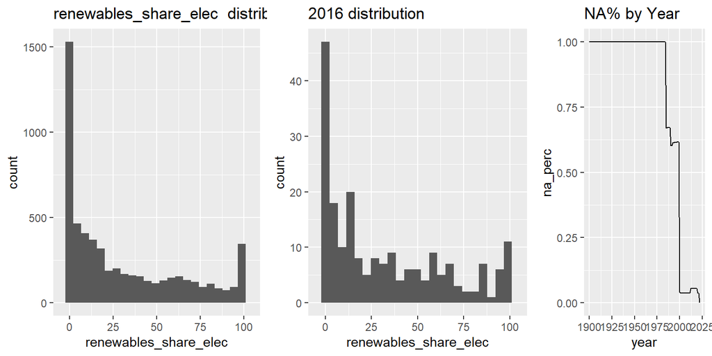

```
## [1] "Top three countries in 2016 for renewables_share_elec : Albania , Bhutan , Central African Republic"
```

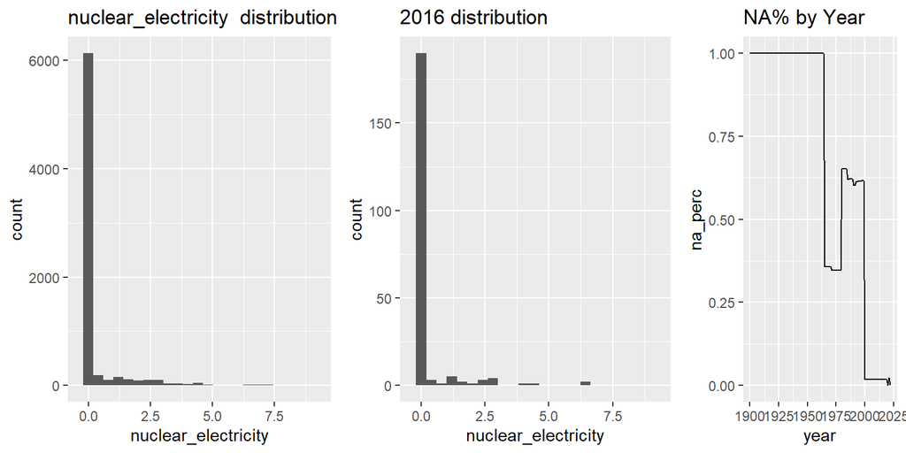

```
## [1] "Top three countries in 2016 for nuclear_electricity : Sweden , France , Finland"
```

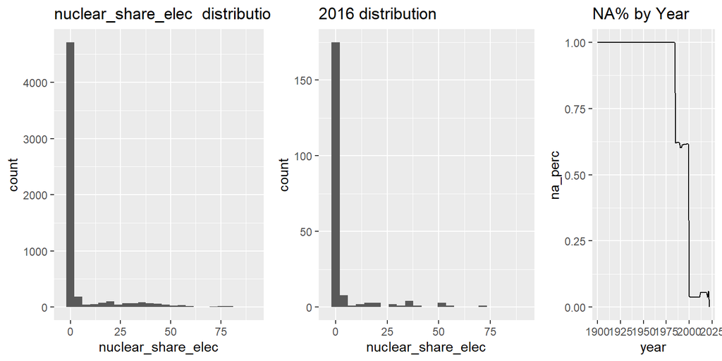

```
## [1] "Top three countries in 2016 for nuclear_share_elec : France , Slovakia , Belgium"
```

[2 more figures not shown]

```
## [1] "Top three countries in 2016 for low_carbon_share_elec : Albania , Bhutan , Central African Republic"
```

```r
for (i in lowcarb){
  do_plots(i)
}
```

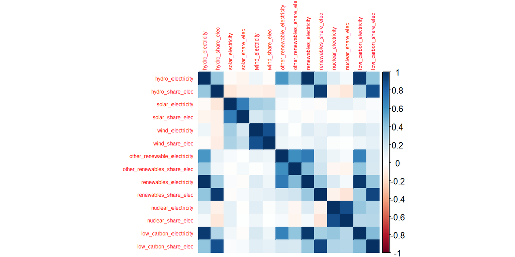

```r
corrplot(cor(mainlog[,lowcarb], use="pairwise.complete.obs"), method="color", tl.cex = .5)
```

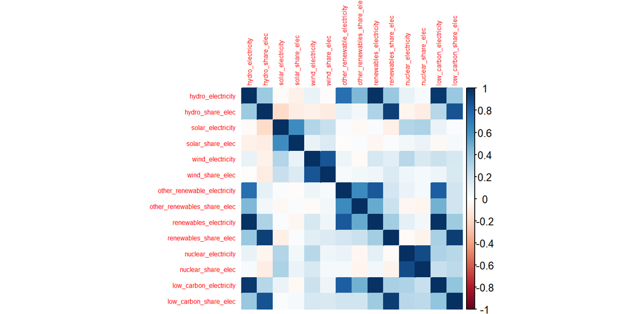

```r
corrplot(cor(mainlog2016[,lowcarb], use="pairwise.complete.obs"), method="color", tl.cex = .5)
```

Again, for **low carbon sources**, we see that most countries only share records from 2000 onwards.

Electricity from low carbon sources mainly comes from **hydro**, with all other sources having distributions close to 0, with some significant outliers. In fact, hydro is almost collinear with overall electricity production and share for renewables and low carbo. The main reason is that hydro is historically the most used renewable source, as it is extremely cheap compared to the other low-carbon sources and has a different purpose than electricity production.

**Solar** and **Wind** are correlated; however, the correlation has gotten weaker over time, this is probably due to the cost of the sources, which came down over the years, so it is feasible for more countries to invest in renewable sources and to do so in the one that best fits the country availability.

### 3.4.4 Analysis on external reserves variables

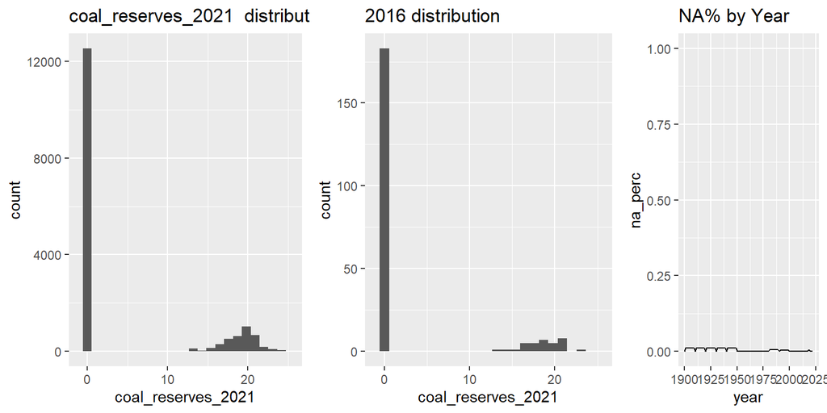

```
## [1] "Top three countries in 2016 for coal_reserves_2021 : Australia , New Zealand , Kazakhstan"
```

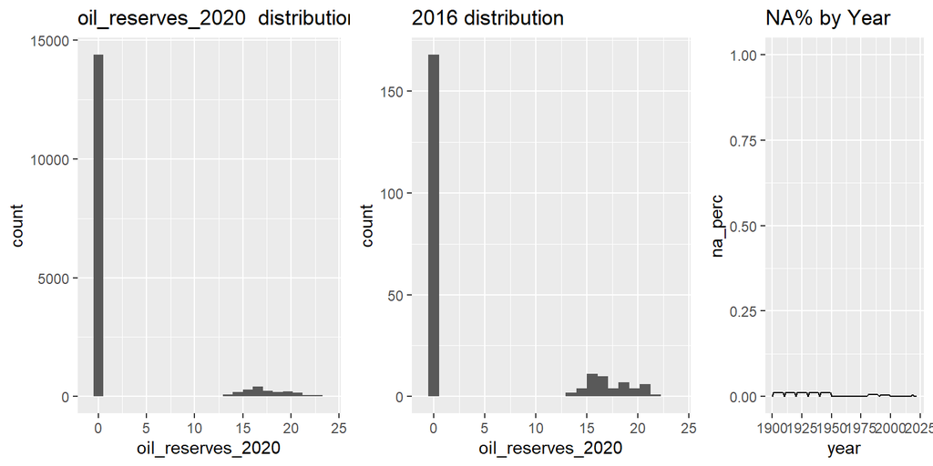

```
## [1] "Top three countries in 2016 for oil_reserves_2020 : Kuwait , United Arab Emirates , Venezuela"
```

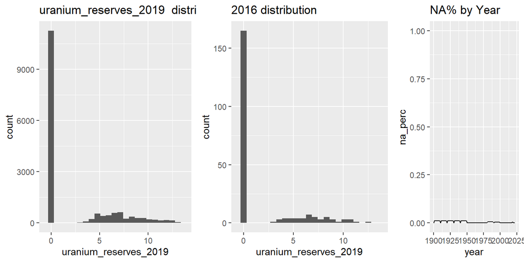

```
## [1] "Top three countries in 2016 for uranium_reserves_2019 : Namibia , Australia , Kazakhstan"
```

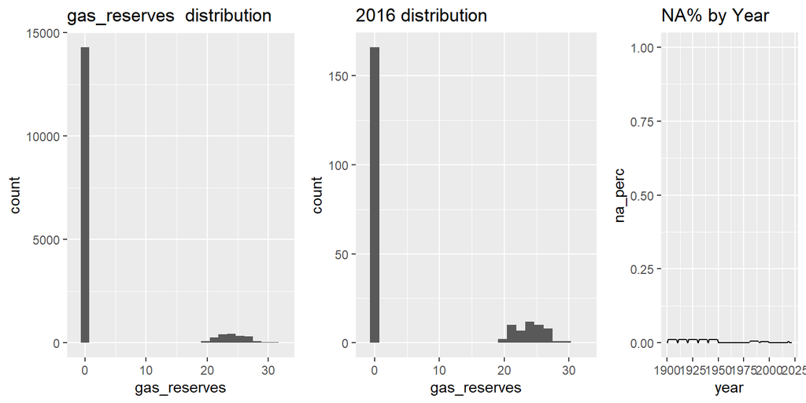

```
## [1] "Top three countries in 2016 for gas_reserves : Qatar , Turkmenistan , United Arab Emirates"
```

```r
for (i in reserves){
  do_plots(i)
}
```

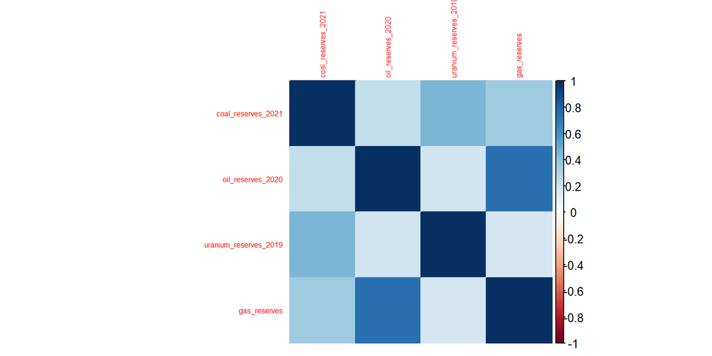

```r
corrplot(cor(mainlog2016[,reserves], use="pairwise.complete.obs"), method="color", tl.cex = .5)
```

Most countries have no reserves,however the distribution of reserves for the countries that do seem to be normally shaped (after transformations). A really interesting insight is that the different types of reserves are correlated between each others.

### 3.4.5 Analysis on other external variables

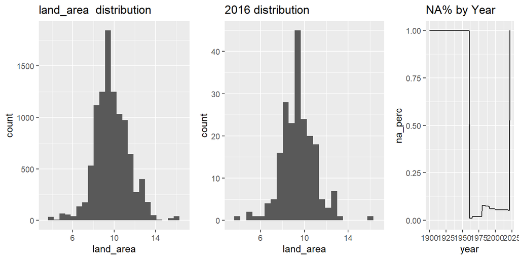

```
## [1] "Top three countries in 2016 for land_area : Greenland , Mongolia , Namibia"
```

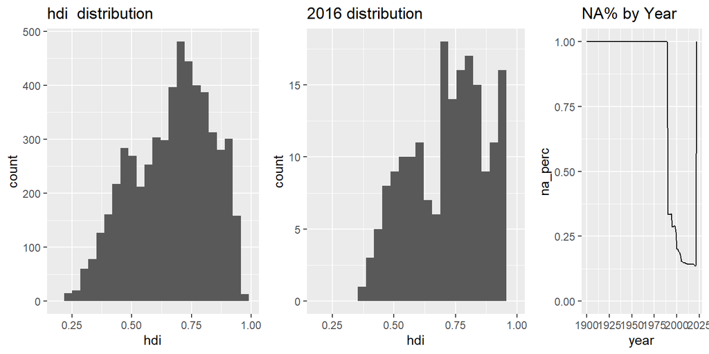

```
## [1] "Top three countries in 2016 for hdi : Switzerland , Norway , Iceland"
```

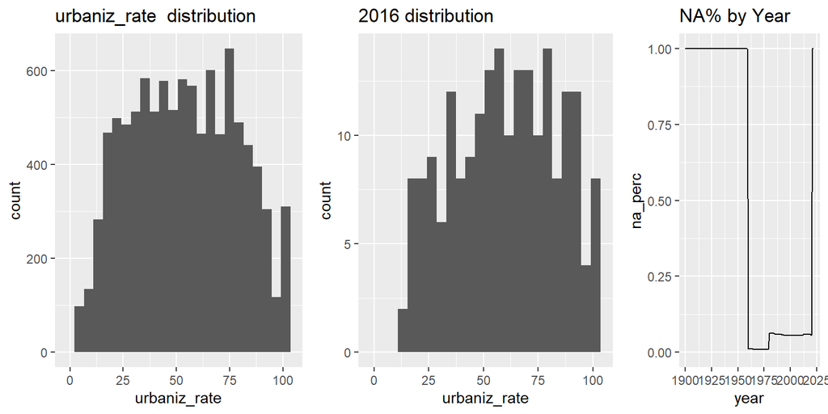

```
## [1] "Top three countries in 2016 for urbaniz_rate : Bermuda , Cayman Islands , Gibraltar"
```

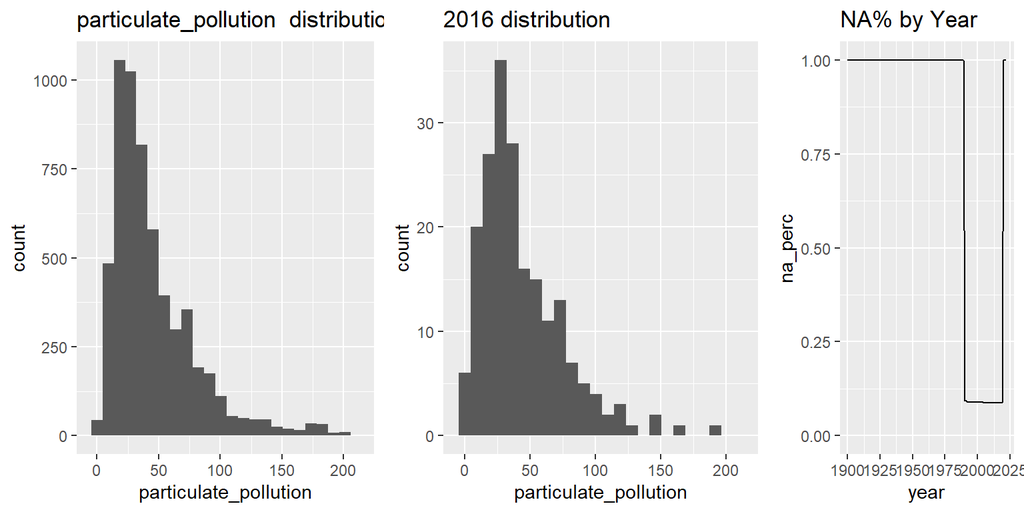

```
## [1] "Top three countries in 2016 for particulate_pollution : Uzbekistan , Egypt , Oman"
```

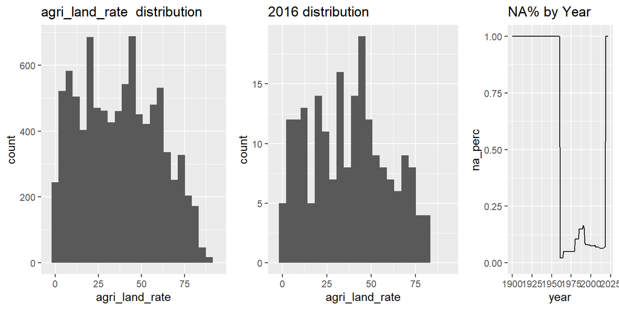

```
## [1] "Top three countries in 2016 for agri_land_rate : Saudi Arabia , Uruguay , Kazakhstan"
```

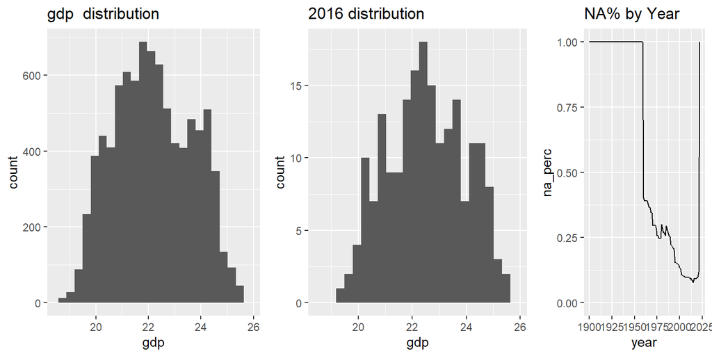

```
## [1] "Top three countries in 2016 for gdp : Luxembourg , Bermuda , Switzerland"
```

```r
for (i in ext_measures){
  do_plots(i)
}
```

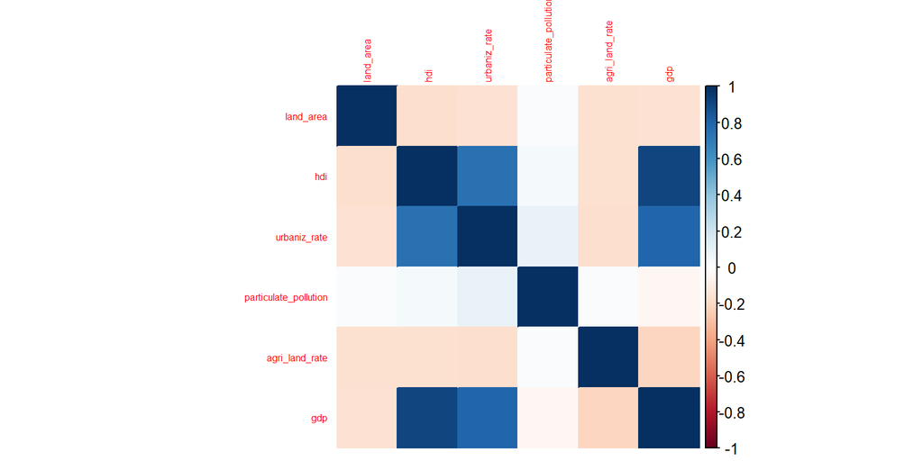

```r
corrplot(cor(mainlog[,ext_measures], use="pairwise.complete.obs"), method="color", tl.cex = .5)
```

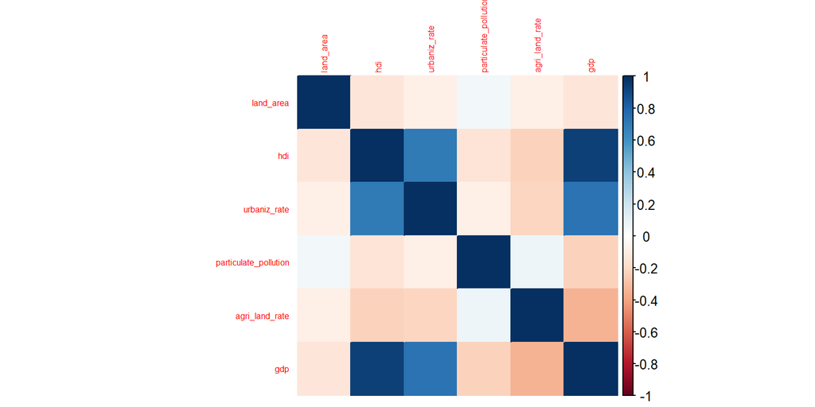

```r
corrplot(cor(mainlog2016[,ext_measures], use="pairwise.complete.obs"), method="color", tl.cex = .5)
```

As expected, **GDP** and **HDI** are strongly correlated; also, urbanization rate has a good correlation with those two variables; all three are slightly negatively correlated to **land area** and **agricultural land rate**. **Particulate pollution** is not correlated to any other variables.

### 3.4.6 Inter-groups correlations

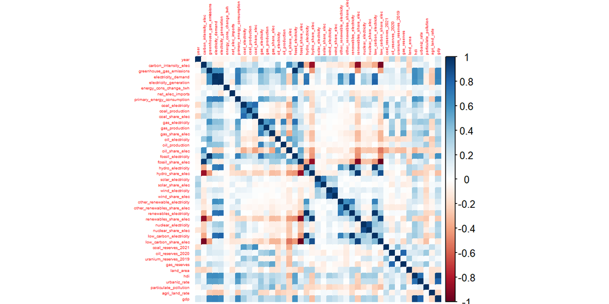

```r
subsetdf = mainlog[,c(2,other_measures,highcarb,lowcarb,reserves,ext_measures)]
subsetdf2016 = mainlog2016[,c(other_measures,highcarb,lowcarb,reserves,ext_measures)]

corrplot(cor(subsetdf, use="pairwise.complete.obs"), method="color", tl.cex = .3)
```

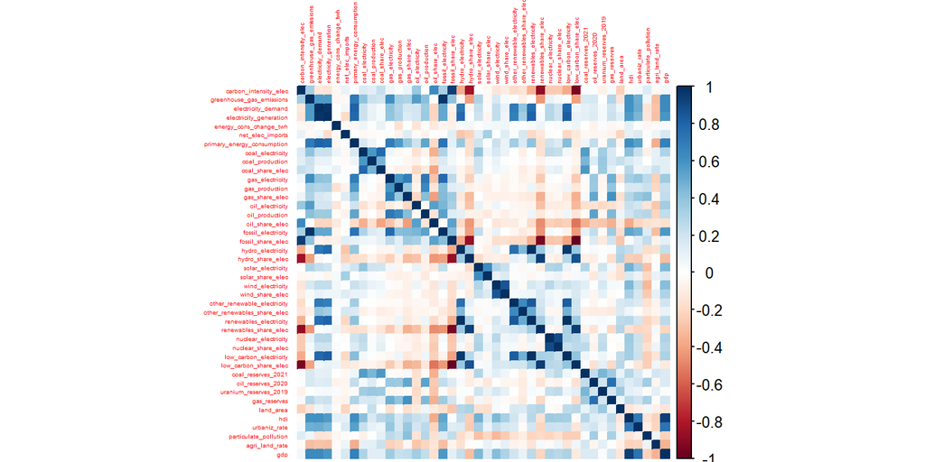

```r
corrplot(cor(subsetdf2016, use="pairwise.complete.obs"), method="color", tl.cex = .3)
```

Finally, we plot correlation among all variables, considering year as one of those. The main findings are the following:

1. **Year** has a slightly positive correlation with **solar** and **wind**, and a slight negative correlation with **coal**.
2. Some noticeable correlations between variables in different groups are renewables (hydro) and fossil sources and their correlation to variables measuring pollution.
3. **Coal** and **gas electricity** productions are correlated to their respective **reserves**, while **oil electricity** has a negative correlation to its **reserves**.
4. **Nuclear** is slightly positively correlated to **uranium reserves**, but it is equally correlated to economic indexes (**GDP**, **HDI**).

# Chapter 4: Descriptive analyses

## 4.1 Global analyses

We start the descriptive analyses by looking at the global low-carbon electricity generation trends. By **low-carbon**, we refer to the electricity produced with substantially lower greenhouse gas emissions than conventional fossil fuel power generation [12]. In other words, the term low-carbon includes renewable and nuclear sources. We will now refer to it with the acronym **LC**.

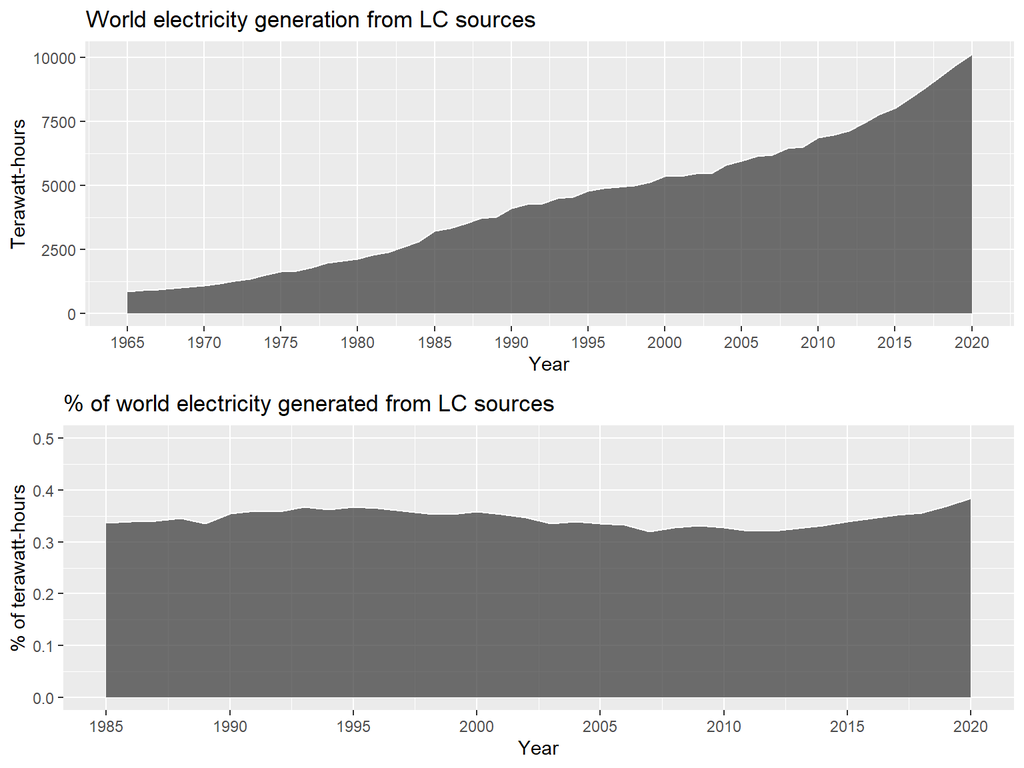

```r
# 1. World electricity generation from LC sources

# a. Area plot of the total generation
# Creation of the dataset
place = main[c("year", "low_carbon_electricity")] %>%
  mutate_all(~replace_na(.,0)) %>%
  group_by(year) %>%
  summarize(sum_lc = sum(low_carbon_electricity))

# Creation of the plot
gg1 = ggplot(place, aes(year, sum_lc)) +
  geom_area(alpha = 0.7, colour="white") +
  scale_x_continuous(limits = c(1965,2020), breaks = seq(1965, 2020, by = 5)) +
  labs(title = "World electricity generation from LC sources",
       x = "Year",
       y = "Terawatt-hours")

# b. Area plot of the ratio between LC generation and total electricity generation
# Creation of the dataset
place = main[c("year", "low_carbon_electricity", "electricity_generation")] %>%
  mutate_all(~replace_na(.,0)) %>%
  group_by(year) %>%
  summarize(sum_lc = sum(low_carbon_electricity)/sum(electricity_generation))

# Creation of the plot
gg2 = ggplot(place, aes(year, sum_lc)) +
  geom_area(alpha = 0.7, colour="white") +
  scale_x_continuous(limits = c(1985,2020), breaks = seq(1985, 2020, by = 5)) +
  scale_y_continuous(limits = c(0,0.5)) +
  labs(title = "% of world electricity generated from LC sources",
       x = "Year",
       y = "% of terawatt-hours")

# Visualization of gg1 and gg2
grid.arrange(gg1,gg2)
```

Nonetheless, the second image clarifies an important point: even if the electricity generation from LC sources increased, the share of world electricity generated from LC sources has been stationary over the years, except for a timid increase from 2013 to 2020.

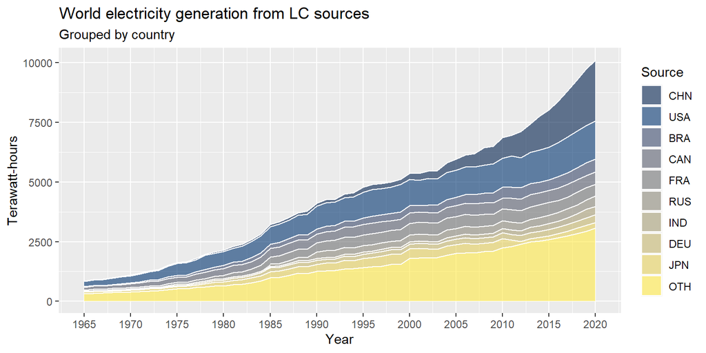

```r
# 2. World electricity generation from LC sources, grouped by countries

# a. Creation of a vector containing the ISO codes of the nine countries with the highest
# LC electricity production in 2020
place = main[c("year", "low_carbon_electricity")] %>% mutate_all(~replace_na(.,0))
place = cbind(iso_code = main$iso_code, place) %>%
  filter(year == 2020) %>%
  arrange(desc(low_carbon_electricity))
place_2 = place$iso_code[1:9]

# b. Group the other countries in a single class called "OTH" ("others")
place = main[c("year", "low_carbon_electricity")] %>% mutate_all(~replace_na(.,0))
place = cbind(iso_code = main$iso_code, place)
for(i in 1:nrow(place)){
  place$iso_code[i] = ifelse(place$iso_code[i] %in% place_2, place$iso_code[i], "OTH")
}
place = group_by(place, iso_code, year) %>%
  summarize(sum_lc = sum(low_carbon_electricity))
place$iso_code = factor(place$iso_code,
                        levels = c("CHN", "USA", "BRA", "CAN", "FRA", "RUS",
                                   "IND", "DEU", "JPN", "OTH"))

#  c. Plot the graph
gg1 = ggplot(place, aes(year, sum_lc, fill = iso_code)) +
  geom_area(alpha=0.6, colour="white") +
  scale_x_continuous(limits = c(1965,2020), breaks = seq(1965, 2020, by = 5)) +
  labs(title = "World electricity generation from LC sources",
       subtitle = "Grouped by country",
       x = "Year",
       y = "Terawatt-hours") +
  scale_fill_viridis_d(name = "Source", option = "E")

# d. Share of electricity production by country in 2020
place = filter(place, year == 2020)
place$sum_lc = round(place$sum_lc / sum(place$sum_lc),2)
place = place[,c(1,3)] %>% arrange(desc(sum_lc)) %>% as.data.frame()
colnames(place) = c("ISO code","% LC generation")

# Plot gg1 and table
gg1
```

```r
kable(cbind(place[1:5,], place[6:10,]),caption = "Share of LC electricity generation by country, 2020")
```

Share of LC electricity generation by country, 2020

| ISO code | % LC generation | ISO code | % LC generation |
| --- | --- | --- | --- |
| OTH | 0.30 | FRA | 0.05 |
| CHN | 0.25 | IND | 0.04 |
| USA | 0.16 | RUS | 0.04 |
| BRA | 0.05 | DEU | 0.03 |
| CAN | 0.05 | JPN | 0.02 |

Not surprisingly, the generation of electricity from LC sources is not homogeneous between the countries: China and the USA own 41% of the electricity generated in 2020; the nine nations with the highest electricity generation from LC sources account for 69%.

## 4.2 Analyses by source

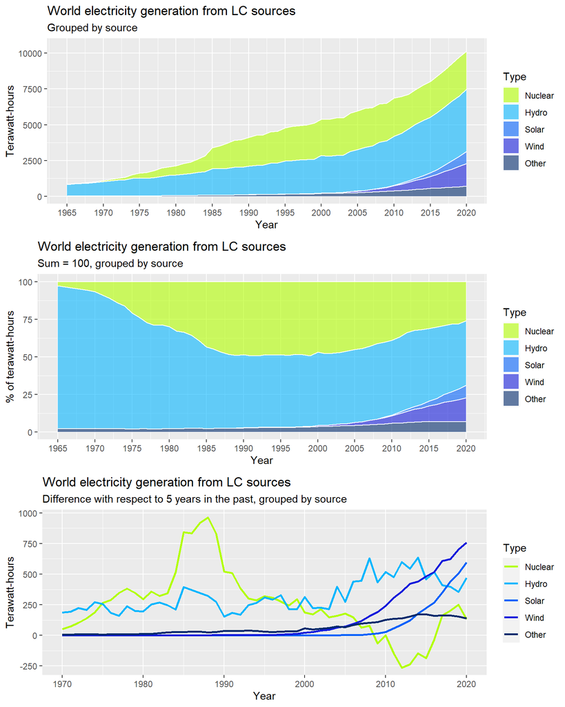

```r
# 3. World electricity generation from LC sources, grouped by source

# a. Area plot of the total electricity generation
# Creation of the dataset
place = main[c("year", "hydro_electricity",
                               "nuclear_electricity", "solar_electricity", "wind_electricity",
                               "other_renewable_electricity")] %>%
  mutate_all(~replace_na(.,0)) %>%
  group_by(year) %>%
  summarize(Nuclear = sum(nuclear_electricity),
            Hydro = sum(hydro_electricity),
            Wind = sum(wind_electricity),
            Solar = sum(solar_electricity),
            Other = sum(other_renewable_electricity)) %>%
  gather(key = "Type",
         value = "elect",
         -year)
place$Type = factor(place$Type, levels = c("Nuclear", "Hydro", "Solar",
                                           "Wind", "Other"))

# Creation of the plot
gg1 = ggplot(place, aes(year, elect, fill = Type)) +
  geom_area(alpha=0.6 , size=.5, colour="white")+
  scale_x_continuous(limits = c(1965,2020), breaks = seq(1965, 2020, by = 5)) +
  scale_y_continuous(limits = c(0,10500)) +
  scale_fill_manual(values = c("#B2FF00", "#05B6FF", "#0060FA", "#141BDB", "#00296B")) +
  labs(title = "World electricity generation from LC sources",
       subtitle = "Grouped by source",
       x = "Year",
       y = "Terawatt-hours")

# b. Area plot of the total electricity generation, with sum = 100
# Creation of the dataset
place = main[c("year","hydro_electricity", "wind_electricity",
               "nuclear_electricity", "solar_electricity",
               "other_renewable_electricity")] %>%
  mutate_all(~replace_na(.,0)) %>%
  group_by(year) %>%
  summarize(Nuclear = sum(nuclear_electricity),
            Hydro = sum(hydro_electricity),
            Wind = sum(wind_electricity),
            Solar = sum(solar_electricity),
            Other = sum(other_renewable_electricity)) %>%
  select(Nuclear, Hydro, Wind, Solar,
         Other, Nuclear) %>%
  mutate(year = 1900:2022, row_total = rowSums(.)) %>%
  mutate(across(Nuclear:Other, ~ . / row_total * 100)) %>%
  select(-row_total) %>%
  gather(key = "Type",
         value = "elect",
         -year)
place$Type = factor(place$Type, levels = c("Nuclear", "Hydro", "Solar",
                                           "Wind", "Other"))

# Creation of the plot
gg2 = ggplot(place, aes(year, elect, fill = Type)) +
  geom_area(alpha=0.6 , size=.5, colour="white")+
  scale_x_continuous(limits = c(1965,2020), breaks = seq(1965, 2020, by = 5)) +
    scale_fill_manual(values = c("#B2FF00", "#05B6FF", "#0060FA", "#141BDB", "#00296B")) +
      labs(title = "World electricity generation from LC sources",
       subtitle = "Sum = 100, grouped by source",
       x = "Year",
       y = "% of terawatt-hours")

# c. Line plot of the difference of generation with respect to 5 years in the past
# Creation of the dataset
place = main[c("year", "hydro_electricity", "nuclear_electricity",
               "solar_electricity", "wind_electricity",
               "other_renewable_electricity")] %>%
  mutate_all(~replace_na(.,0)) %>%
  filter(year <= 2020) %>%
  group_by(year) %>%
  summarize(Nuclear = sum(nuclear_electricity),
            Hydro = sum(hydro_electricity),
            Wind = sum(wind_electricity),
            Solar = sum(solar_electricity),
            Other = sum(other_renewable_electricity)) %>%
  mutate(Nuclear = (Nuclear - dplyr::lag(Nuclear,5)),
         Hydro = (Hydro - dplyr::lag(Hydro,5)),
         Wind = (Wind - dplyr::lag(Wind,5)),
         Solar = (Solar - dplyr::lag(Solar,5)),
         Other = (Other - dplyr::lag(Other,5))) %>%
  gather(key = "Type",
         value = "world_elect",
         -year)
place$Type = factor(place$Type, levels = c("Nuclear", "Hydro", "Solar",
                                                "Wind", "Other"))

# Creation of the plot
gg3 = ggplot(place, aes(year, world_elect, colour = Type)) +
  geom_line(size = 1) +
  scale_x_continuous(limits = c(1970,2020)) +
  scale_y_continuous() +
  scale_color_manual(values = c("#B2FF00", "#05B6FF", "#0060FA", "#141BDB", "#00296B")) +
    labs(title = "World electricity generation from LC sources",
       subtitle = "Difference with respect to 5 years in the past, grouped by source",
       x = "Year",
       y = "Terawatt-hours")

# Visualization of gg1, gg2 and gg3
grid.arrange(gg1, gg2, gg3)
```

The plots allow us to identify three different phases in the history of LC electricity.

1. **Dawn of LC electricity** (up to the mid-’80s). In this era, there are two different trends: on one side, the electricity generated by hydropower grows linearly with respect to the past generation; on the other side, the civil usage of nuclear power takes the first steps.
2. **Golden age of nuclear electricity** (from the mid-’80s to mid-’00s). The electricity generation from nuclear reaches its peak, while the production of hydropower plants continues to grow linearly.
3. **Golden age of renewables** (from the mid-’00s to nowadays). Nuclear power generation declines and gives way to renewables. In particular, the solar and wind generation skyrockets.

## 4.3 Analyses by macroregion

We are now interested in analyzing electricity generation by LC sources in different areas. To do so, we aggregate world countries into six macroregions based on geographical, economic, and cultural factors.

1. **Developed countries**: Western Europe, Israel, USA, Canada, Australia, New Zealand, Japan, South Korea, Taiwan, Hong Kong, and Macao.
2. **Latin America and the Caribbean**: North and South America’s countries, except for USA and Canada.
3. **Eastern Europe**: former members of the Warsaw Pact (excluding Kazakhstan, Turkmenistan, Uzbekistan, Tajikistan, and Kyrgyzstan) and former Yugoslavia.
4. **Middle East and Northern Africa**: Morocco, Algeria, Tunisia, Libya, Egypt, Jordan, Palestine, Lebanon, Syria, Turkey, Iraq, Iran, Kuwait, Saudi Arabia, Yemen, Oman, United Arab Emirates, Bahrain, and Qatar.
5. **Sub-Saharan Africa**: non-aforementioned African countries.
6. **Asia**: non-aforementioned Asian countries.

```r
# a. Creation of a vector for each macroregion, containing the ISO-codes
developed_countries = c("AUS", "AUT", "BEL", "CAN", "CYP", "DNK", "FRO", "FIN",
                        "FRA", "DEU", "GRC", "GRL", "HKG", "ISL", "IRL", "ISR",
                        "ITA", "JPN", "LUX", "MAC", "MLT", "NLD", "NZL", "NOR",
                        "PRT", "SPM", "KOR", "ESP", "SWE", "CHE", "TWN", "GBR",
                        "USA", "REU", "GIB")

latin_countries = c("ATG", "ARG", "ABW", "BHS", "BRB", "BLZ", "BMU", "BOL",
                    "BRA", "CYM", "CHL", "COL", "CRI", "CUB", "DMA", "DOM",
                    "ECU", "SLV", "FLK", "GUF", "GRD", "GLP", "GTM", "GUY",
                    "HTI", "HND", "JAM", "MTQ", "MEX", "MSR", "NIC", "PAN",
                    "PRY", "PER", "PRI", "KNA", "LCA", "VCT", "SUR", "TTO",
                    "TCA", "VIR", "URY", "VEN", "VGB", "ANT")

east_europe_countries = c("ALB", "ARM", "AZE", "BLR", "BIH", "BGR", "HRV",
                          "CZE", "EST", "GEO", "HUN", "LVA", "LTU", "MDA",
                          "MNE", "MKD", "POL", "ROU", "RUS", "SRB", "SVK",
                          "SVN", "UKR")

sub_african_countries = c("AGO", "BEN", "BWA", "BFA", "BDI", "CPV", "CMR",
                          "CAF", "TCD", "COM", "COG", "CIV", "COD", "DJI",
                          "GNQ", "ERI", "SWZ", "ETH", "GAB", "GMB", "GHA",
                          "GIN", "GNB", "KEN", "LSO", "LBR", "MDG", "MWI",
                          "MLI", "MRT", "MUS", "MOZ", "NAM", "NER", "NGA",
                          "RWA", "STP", "SEN", "SLE", "SOM", "ZAF", "SSD",
                          "SDN", "TZA", "TGO", "UGA", "ZMB", "ZWE", "SHN")

middle_east_countries = c("DZA", "BHR", "EGY", "IRN", "IRQ", "JOR", "KWT",
                          "LBN", "LBY", "MAR", "OMN", "PSE", "QAT", "SAU",
                          "SYR", "TUR", "ARE", "YEM", "TUN")

asian_countries = c("AFG", "ASM", "BGD", "BTN", "BRN", "KHM", "CHN", "COK",
                    "FJI", "PYF", "GUM", "IND", "IDN", "KAZ", "KIR", "KGZ",
                    "LAO", "MYS", "MDV", "FSM", "MNG", "MMR", "NRU", "NPL",
                    "NCL", "PRK", "MNP", "PAK", "PNG", "PHL", "WSM", "VNM",
                    "SYC", "SGP", "SLB", "LKA", "TJK", "THA", "TLS", "TON",
                    "TKM", "TUV", "UZB", "VUT", "NIU")

#b. Assign the grouping to each observation in "main"
tag = rep(0, nrow(main))

for(i in 1:length(tag)){
  if(main$iso_code[i] %in% developed_countries){
    tag[i] = "developed"
  }
  else{
    if(main$iso_code[i] %in% latin_countries){
      tag[i] = "latin"
    }
    else{
      if(main$iso_code[i] %in% east_europe_countries){
        tag[i] = "east_europe"
      }
      else{
        if(main$iso_code[i] %in% sub_african_countries){
          tag[i] = "sub_african"
        }
        else{
          if(main$iso_code[i] %in% middle_east_countries){
            tag[i] = "middle_east"
          }
          else{
            if(main$iso_code[i] %in% asian_countries){
              tag[i] = "asian"
            }
          }
        }
      }
    }
  }
}
main = cbind(main, tag)

# c.Plot of the world map
df_asian = data.frame(region = "Asia", tag = asian_countries)
df_east = data.frame(region = "Eastern Europe", tag = east_europe_countries)
df_middle = data.frame(region = "Mid. East & N. Africa", tag = middle_east_countries)
df_dev = data.frame(region = "Developed", tag = developed_countries)
df_africa = data.frame(region ="Sub-Sah. Africa", tag = sub_african_countries)
df_latin = data.frame(region = "Latin A. & Carr.", tag = latin_countries)
df_world = rbind(df_asian, df_east, df_middle, df_dev, df_africa, df_latin)


map = joinCountryData2Map(df_world, joinCode = "ISO3",
                          nameJoinColumn = "tag")
```

```
## 212 codes from your data successfully matched countries in the map
## 5 codes from your data failed to match with a country code in the map
## 31 codes from the map weren't represented in your data
```

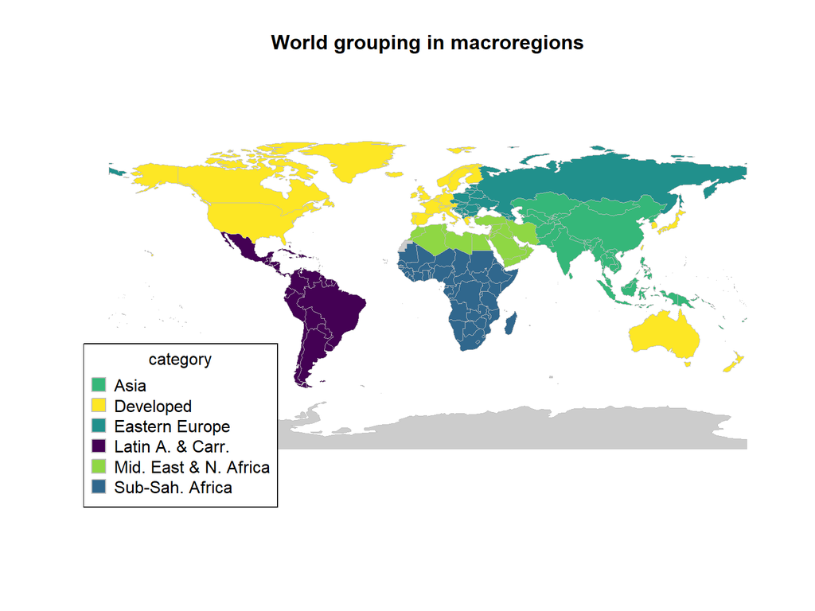

```r
mapCountryData(map, nameColumnToPlot = "region", catMethod = "categorical",
               missingCountryCol = gray(.8),
               colourPalette = c("#35B779", "#FDE725", "#21908C", "#440154",
                                 "#8FD744", "#30678D"),
               mapTitle = "World grouping in macroregions")
```

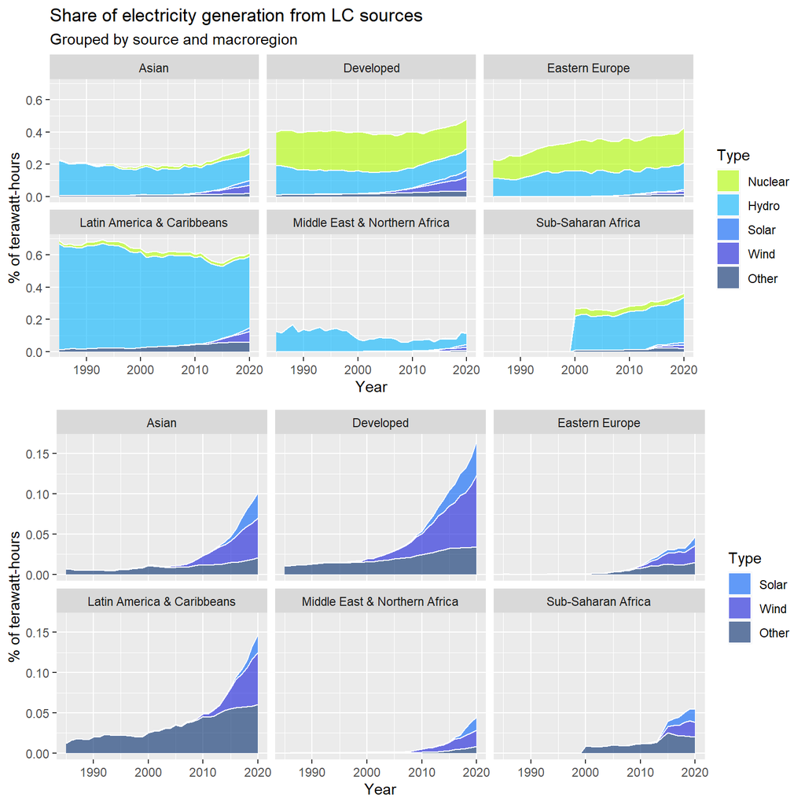

```r
# 3. World electricity generation from LC sources, grouped by macroregion

# a. LC generation by macroregion
# Creation of the dataset
place = main[c("year","hydro_electricity", "wind_electricity",
               "nuclear_electricity", "solar_electricity",
               "other_renewable_electricity", "electricity_generation")] %>%
  mutate_all(~replace_na(.,0)) %>%
  cbind(., tag = main$tag) %>%
  group_by(year, tag) %>%
  summarize(Nuclear = sum(nuclear_electricity)/sum(electricity_generation),
            Hydro = sum(hydro_electricity)/sum(electricity_generation),
            Wind = sum(wind_electricity)/sum(electricity_generation),
            Solar = sum(solar_electricity)/sum(electricity_generation),
            Other = sum(other_renewable_electricity)/sum(electricity_generation)) %>%
  gather(key = "Type",
         value = "elect",
         -year, -tag)
place$Type = factor(place$Type, levels = c("Nuclear", "Hydro", "Solar",
                                           "Wind", "Other"))
# Here we remove data for Sub-Saharan countries from 2000, as data is not available
# for most of the countries
for(i in 1:nrow(place)){
  if(place$year[i] < 2000 & place$tag[i] == "sub_african"){
    place$elect[i] = 0
  }
}

tag_modifier = function(place_data){
  place_data[place_data$tag  == "asian", "tag"] = "Asian"
  place_data[place_data$tag  == "developed", "tag"] = "Developed"
  place_data[place_data$tag  == "east_europe", "tag"] = "Eastern Europe"
  place_data[place_data$tag  == "latin", "tag"] = "Latin America & Caribbeans"
  place_data[place_data$tag  == "middle_east", "tag"] = "Middle East & Northern Africa"
  place_data[place_data$tag  == "sub_african", "tag"] = "Sub-Saharan Africa"
  return(place_data)
}

source_modifier = function(place_data){
  place_data[place_data$Source  == "nuclear_share_elec", "Source"] = "Nuclear"
  place_data[place_data$Source  == "hydro_share_elec", "Source"] = "Hydro"
  place_data[place_data$Source  == "solar_share_elec", "Source"] = "Solar"
  place_data[place_data$Source  == "wind_share_elec", "Source"] = "Wind"
  place_data[place_data$Source  == "other_renewables_share_elec", "Source"] = "Other"

  place_data$Source = factor(place_data$Source, levels = c("Nuclear", "Hydro", "Solar", "Wind",
                                               "Other"))
  return(place_data)
}

place = tag_modifier(place)


# Creation of the plot
gg1 = ggplot(place, aes(year, elect, fill = Type)) +
  geom_area(alpha=0.6 , size=.5, colour="white")+
  scale_x_continuous(limits = c(1985,2020)) +
  scale_fill_manual(values = c("#B2FF00", "#05B6FF", "#0060FA", "#141BDB", "#00296B")) +
  facet_wrap(~ tag, nrow = 2) +
  labs(title = "Share of electricity generation from LC sources",
       subtitle = "Grouped by source and macroregion",
       x = "Year",
       y = "% of terawatt-hours")

# b. Plot of renewables generation by macroregion, excluding hydropower
# Creation of the dataset
place = filter(place, Type == "Solar" | Type == "Wind" | Type == "Other")

# Creation of the plot
gg2 = ggplot(place, aes(year, elect, fill = Type)) +
  geom_area(alpha=0.6 , size=.5, colour="white")+
  scale_x_continuous(limits = c(1985,2020)) +
  scale_fill_manual(values = c("#0060FA", "#141BDB", "#00296B")) +
  facet_wrap(~ tag, nrow = 2) +
  labs(x = "Year",
       y = "% of terawatt-hours")

# Visualization of gg1, gg2 and gg3
grid.arrange(gg1, gg2, ncol=1)
```

A variety of conclusions can be drawn from the previous graphs. Here we present the four main findings.

1. The different areas are **not homogeneous** in electricity generation from low-carbon sources: Latin American countries have a more significant share; developed, Eastern European and Sub-Saharan and Asian follow; Middle-East generation is negligible.
2. **Hydropower** is an essential source of electricity in all the considered macroregions.
3. **Nuclear electricity** is significant only in developed countries and Eastern Europe; its importance is comparable to hydropower generation in those macroregions.
4. Developed countries drive **non-hydropower renewable** production. Nonetheless, it is also true that those sources are also rapidly becoming more relevant in Latin America and Asia.

It is important to highlight also that a lower total electricity generation heavily influences Asian, Latin American, and (especially) Sub-Saharan generation rates, as the graph below shows.

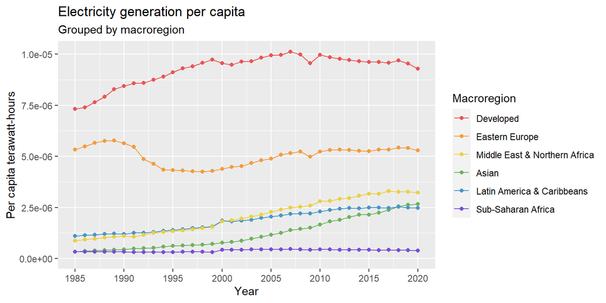

```r
# Focus on electricity generation per capita
# Creation of the dataset
place = main[c("year","electricity_generation", "population")] %>%
  mutate_all(~replace_na(.,0)) %>%
  cbind(., tag = main$tag) %>%
  group_by(tag,year) %>%
  summarize(gen_per_capita = sum(electricity_generation)/sum(population))

place = tag_modifier(place)
place$tag = factor(place$tag, levels = c("Developed", "Eastern Europe",
                                         "Middle East & Northern Africa",
                                         "Asian", "Latin America & Caribbeans",
                                         "Sub-Saharan Africa"))
colnames(place) = c("Macroregion","year","gen_per_capita")


# Creation of the plot
ggplot(place, aes(year, gen_per_capita, color = Macroregion)) +
  geom_line() +
  geom_point() +
  scale_x_continuous(limits = c(1985,2020), breaks = seq(1985, 2020, by = 5)) +
  scale_color_manual(values = c("#EA5555", "#F39C3C", "#ECD03F", "#6EB35E", "#4996C8",
                                "#774ED8")) +
  labs(title = "Electricity generation per capita",
       subtitle = "Grouped by macroregion",
       x = "Year",
       y = "Per capita terawatt-hours")
```

The electricity generation from non-hydro renewable sources in Sub-Saharan Africa increases rapidly between 2011 and 2015. Therefore, we studied the behavior of the five countries in the region with the highest non-hydro renewable electricity generation in 2015. As the plot shows, the steep increase is simply due to an exploding generation from solar and wind sources in South Africa.

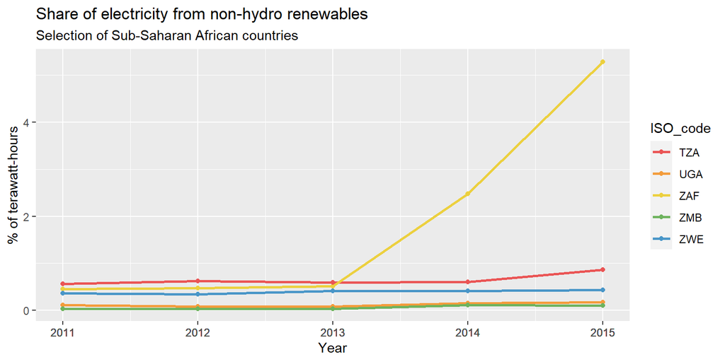

```r
suppressMessages({
# Extract the LC production grouped by source from 2011 to 2015 of the five countries
# with the highest renewables production in 2015

#a. Extract the ISO of five countries with the highest non-hydro renewables generation
#   in 2015
place = select(main, iso_code, year, renewables_electricity, hydro_electricity) %>%
  filter(year == 2015 & tag == "sub_african") %>%
  mutate(non_hydro_elec = renewables_electricity - hydro_electricity) %>%
  arrange(desc(non_hydro_elec)) %>%
  select(iso_code) %>%
  top_n(5) %>%
  as.data.frame()

# b. Creation of the dataset
place = select(main, year, iso_code, renewables_electricity, hydro_electricity) %>%
  filter(year <= 2015 & year >= 2011 & iso_code %in% place$iso_code) %>%
  mutate(non_hydro_elec = renewables_electricity - hydro_electricity)
colnames(place) = c(colnames(place)[1], "ISO_code", colnames(place)[3:5])

# c. Creation the plot
ggplot(place, aes(year, non_hydro_elec, color = ISO_code)) +
  geom_line(size = 1) +
  geom_point(size = 1.5) +
  scale_x_continuous(limits = c(2011,2015), breaks = place$year) +
  scale_color_manual(values = c("#EA5555", "#F39C3C", "#ECD03F", "#6EB35E", "#4996C8")) +
    labs(title = "Share of electricity from non-hydro renewables",
       subtitle = "Selection of Sub-Saharan African countries",
       x = "Year",
       y = "% of terawatt-hours")
})
```

## 4.4 Green Score with focus on the sources

In this section, we aim to study which countries are nearer to the full LC target (i.e., to produce from LC sources all the electricity they consume). To do so, we create a **Green Score**, defined as the following ratio:
$$\text{GS} = \frac{\text{electricity generated from LC sources}}{{\text{electricity demand}}}$$
Note that in paragraphs 4.4 and 4.5 analyses, we removed the countries with a smaller population than 500,000. The reason is that we expect those countries to be too small to have a significant independent electricity policy with respect to their neighbors.

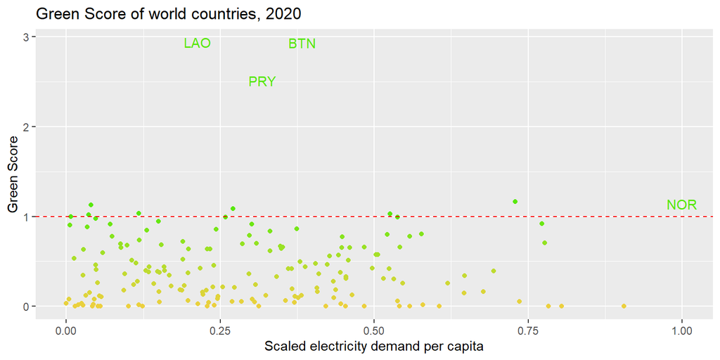

```r
# Note. x is computed as the squared root of the electricity demand per capita, scaled in
# the interval [0,1]. We plot the electricity demand per capita to distinguish if the
# high Green Score is due to low electricity consumption or good green policies. We
# choose the described scaling because it allows for spacing more points in the graph.

# Scatterplot of the Green Score in 2020 in each country
# Creation of the dataset
place = filter(main, (year == 2020 & population > 500000 & iso_code != "REU")) %>%
  transform(elec_demand_per_capita = (
    sqrt(electricity_demand / population) -
      min(sqrt(electricity_demand / population))) /
      (max(sqrt(electricity_demand / population)) -
         min(sqrt(electricity_demand / population))),
    green_score_renew = renewables_electricity / electricity_demand,
    green_score_lc = low_carbon_electricity / electricity_demand) %>%
  select(iso_code, elec_demand_per_capita, green_score_renew, green_score_lc)

# Creation of the plot
ggplot()+
  geom_point(data = filter(place, iso_code != "LAO", iso_code != "BTN",
                           iso_code != "PRY", iso_code != "NOR"),
             mapping = aes(elec_demand_per_capita, green_score_lc,
                           color = green_score_lc)) +
  geom_text(data = filter(place, iso_code == "LAO" | iso_code == "BTN" |
                            iso_code == "PRY" | iso_code == "NOR"),
            mapping = aes(elec_demand_per_capita, green_score_lc,
                          label = iso_code, color = green_score_lc)) +
  geom_hline(yintercept = 1, linetype = "dashed", color = "red") +
  scale_color_gradient(low = "#ECD03F", high = "#59E80C", na.value = "#59E80C",
                       limits = c(0,1), guide = "none") +
  labs(title = "Green Score of world countries, 2020",
       x = "Scaled electricity demand per capita",
       y = "Green Score")
```

The plot highlights **four main outliers**: Laos, Bhutan, and Paraguay, with an overscaled Green Score and a low electricity demand per capita; Norway, with a positive Green Score while being the country with the highest electricity demand per capita. We want to understand if they have shared features that allow us to explain their outperformance.

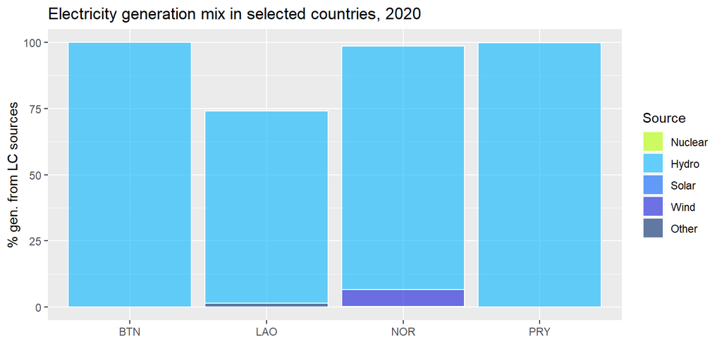

```r
# Barplot of the electricity generation mix in LAO, BTN, PRY and NOR
# Creation of the dataset
place = filter(main, (year == 2020 & (iso_code == "LAO" | iso_code == "BTN" |
                                        iso_code == "PRY" | iso_code == "NOR"))) %>%
  select(iso_code, solar_share_elec, wind_share_elec, hydro_share_elec,
         nuclear_share_elec, other_renewables_share_elec) %>%
  gather(key = "Source", value = "value", -iso_code)

# The following function modify the names of the sources to enchance the visualization
source_modifier = function(place_data){
  place_data[place_data$Source  == "nuclear_share_elec", "Source"] = "Nuclear"
  place_data[place_data$Source  == "hydro_share_elec", "Source"] = "Hydro"
  place_data[place_data$Source  == "solar_share_elec", "Source"] = "Solar"
  place_data[place_data$Source  == "wind_share_elec", "Source"] = "Wind"
  place_data[place_data$Source  == "other_renewables_share_elec", "Source"] = "Other"

  place_data$Source = factor(place_data$Source, levels = c("Nuclear", "Hydro", "Solar", "Wind",
                                               "Other"))
  return(place_data)
}

place = source_modifier(place)


# Creation of the plot
ggplot(place, aes(x = iso_code, y = value, fill = Source)) +
  geom_bar(position = "stack", stat = "identity", alpha = 0.6, colour = "white") +
  scale_fill_manual(values = c("#B2FF00", "#05B6FF", "#0060FA", "#141BDB", "#00296B")) +
  labs(title = "Electricity generation mix in selected countries, 2020",
       x = "",
       y = "% gen. from LC sources")
```

The high performance of the countries is due to a **dominant hydroelectric generation**. For example, further research on the topic highlights that Laos aims to become the “Battery of Southeast Asia” by further exploiting its impressive hydropower potential [13]. So those countries can achieve such an impressive result because of a resource not available everywhere.

Nonetheless, some countries have great hydropower generation but do not exploit it: for instance, the Democratic Republic of Congo has a potential of 100.000 MW (more than four times the biggest hydropower plant in the world, the Three Gorges Dam [14]), but uses only 2.5% of it due to political instability and lack of investments [15].

We then analyze further the correlation between each LC source and the Green Score.

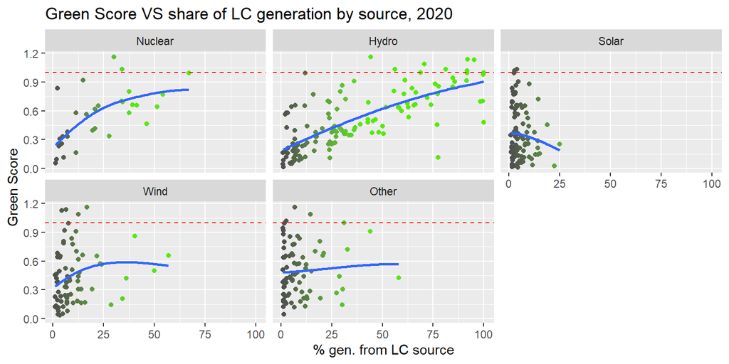

```r
# Scatterplot of the green Score VS share of electricity produced from each LC source
# Creation of the dataset
place = filter(main, year == 2020) %>%
  transform(green_score_lc = (low_carbon_electricity / electricity_demand)) %>%
  select(iso_code, green_score_lc, nuclear_share_elec, hydro_share_elec,
         solar_share_elec, wind_share_elec, other_renewables_share_elec,
         green_score_lc) %>%
  filter(complete.cases(.)) %>%
  gather(key = "Source", value = "value", -iso_code, -green_score_lc) %>%
  # We excluded countries with an irrelevant production from each source
  filter(value > 1)

place = source_modifier(place)

# Creation of the plot
ggplot(filter(place, iso_code != "LAO", iso_code != "BTN", iso_code != "PRY"),
       aes(value, green_score_lc, color = value)) +
  geom_point() +
  geom_smooth(method = "loess", span = 2, se = FALSE, size = 1) +
  geom_hline(yintercept = 1, linetype = "dashed", color = "red") +
  scale_color_gradient(low = "grey30", high = "#59E80C", na.value = "#59E80C",
                       limits = c(0,40),
                       guide = "none") +
  facet_wrap(~Source, nrow = 2) +
  labs(title = "Green Score VS share of LC generation by source, 2020",
       x = "% gen. from LC source",
       y = "Green Score")
```

```r
# Note. "loess" is a statistical technique used for estimating smooth curves in
# scatterplot data. It works by fitting multiple local regression models
# to different subsets of the data, allowing it to capture non-linear patterns and
# relationships between variables. It was introduced in the following plot only to
# highlight better the trends from a graphical point of view.
```

The plot confirms the correlation between the Green Score and the electricity generation from hydropower. It also shows an important link with nuclear power production but not with solar, wind, and other sources.

## 4.5 Green Score with focus on the macroregions

In this final section of descriptive analyses, we focus on the analysis of the Green Score in each country.

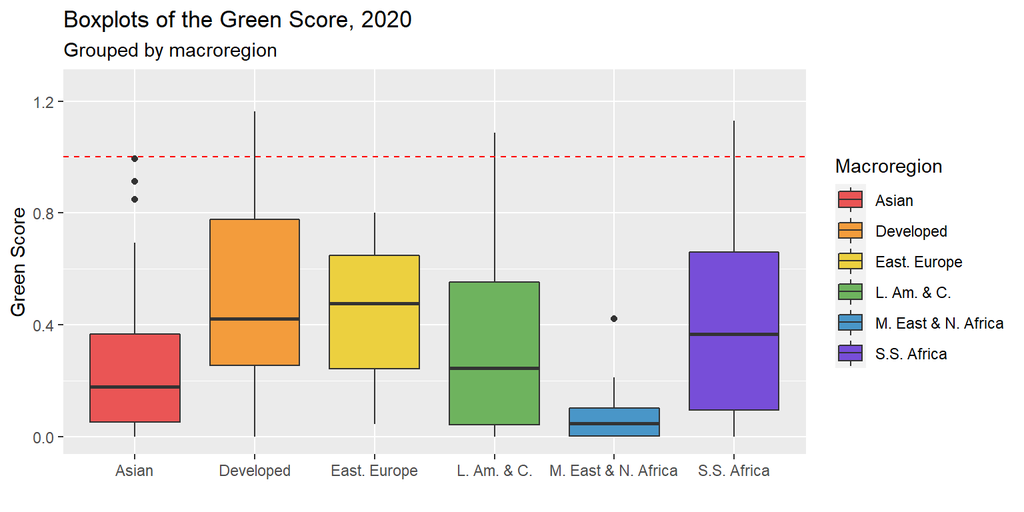

```r
# Boxplot of the Green Score
# Creation of the dataset
place = filter(main, year == 2020) %>%
  transform(green_score_lc = (low_carbon_electricity / electricity_demand)) %>%
  select(iso_code, tag, green_score_lc)

place[place$tag  == "asian", "tag"] = "Asian"
place[place$tag  == "developed", "tag"] = "Developed"
place[place$tag  == "east_europe", "tag"] = "East. Europe"
place[place$tag  == "latin", "tag"] = "L. Am. & C."
place[place$tag  == "middle_east", "tag"] = "M. East & N. Africa"
place[place$tag  == "sub_african", "tag"] = "S.S. Africa"

colnames(place) = c("iso_code", "Macroregion", "green_score_lc")

# Creation of the plot
ggplot(place, aes(x = Macroregion, y = green_score_lc)) +
  geom_boxplot(aes(fill = Macroregion)) +
  ylim(0,1.25) +
  scale_fill_manual(values = c("#EA5555", "#F39C3C", "#ECD03F", "#6EB35E", "#4996C8",
                                "#774ED8")) +
  geom_hline(yintercept = 1, linetype = "dashed", color = "red") +
    labs(title = "Boxplots of the Green Score, 2020",
         subtitle = "Grouped by macroregion",
       x = "",
       y = "Green Score")
```

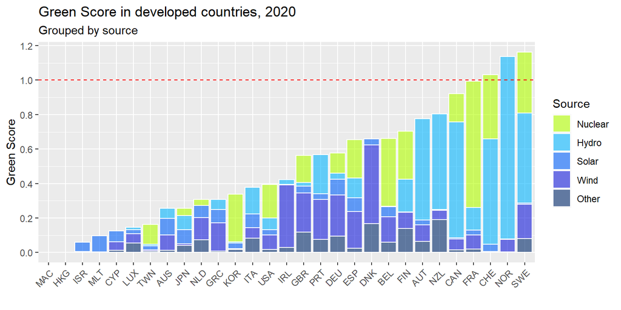

```r
# Barplot of the Green Score
# Creation of the dataset
place = filter(main, year == 2020, !is.na(other_renewables_share_elec),
               population >= 500000) %>%
  transform(ratio = (low_carbon_electricity / (electricity_demand * low_carbon_share_elec))) %>%
  transform(solar_share_elec = ratio * solar_share_elec,
            wind_share_elec = ratio * wind_share_elec,
            hydro_share_elec = ratio * hydro_share_elec,
            nuclear_share_elec = ratio * nuclear_share_elec,
            other_renewables_share_elec = ratio * other_renewables_share_elec) %>%
  select(iso_code, tag, solar_share_elec, wind_share_elec,
         hydro_share_elec, nuclear_share_elec, other_renewables_share_elec) %>%
  # There are NaN values obtain because of division by zero. We want them to be 0
  mutate(across(where(is.numeric), ~ ifelse(is.nan(.), 0, .))) %>%
  # There are NA values. We want to remove them
  gather(key = "Source", value = "value", -iso_code, -tag)

place = source_modifier(place)

# Creation of the plot for the developed countries
ggplot(filter(place, tag == "developed"),
       aes(x = reorder(iso_code, value), y = value, fill = Source)) +
  geom_bar(position = "stack", stat = "identity", alpha = 0.6, colour = "white") +
  scale_fill_manual(values = c("#B2FF00", "#05B6FF", "#0060FA", "#141BDB", "#00296B")) +
  scale_y_continuous(breaks = seq(0, 1.2, by = 0.2)) +
  geom_hline(yintercept = 1, linetype = "dashed", color = "red") +
  labs(title = "Green Score in developed countries, 2020",
       subtitle = "Grouped by source",
       x = "",
       y = "Green Score") +
  theme(axis.text.x = element_text(angle = 45, hjust = 1))
```

The developed countries with the highest Green Scores are **Sweden**, Norway, Switzerland, and France. In contrast, the ones with the lowest values are Macao, Hong Kong, Israel, and Malta.

The LC sources are heterogeneous: while countries like Norway, Switzerland, and Canada are mainly driven by hydropower, others like France and Belgium mainly generate electricity from nuclear power, and others still, like Denmark and Ireland, are mainly driven by non-hydro renewables.

It is also interesting to highlight that the developed Asian countries tend to have a lower score than the others: Japan is the second-best-performing Asian country, but it outperforms only Australia, Luxembourg, Cyprus, and Malta.

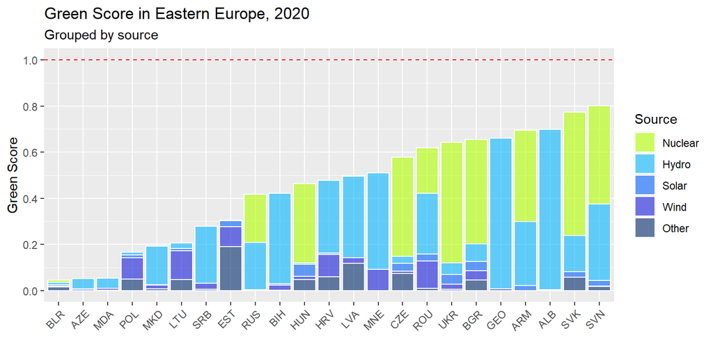

```r
# Creation of the plot for Eastern Europe
ggplot(filter(place, tag == "east_europe"),
       aes(x = reorder(iso_code, value), y = value, fill = Source)) +
  geom_bar(position = "stack", stat = "identity", alpha = 0.6, colour = "white") +
  scale_fill_manual(values = c("#B2FF00", "#05B6FF", "#0060FA", "#141BDB", "#00296B")) +
    scale_y_continuous(breaks = seq(0, 1, by = 0.2)) +
  geom_hline(yintercept = 1, linetype = "dashed", color = "red") +
  labs(title = "Green Score in Eastern Europe, 2020",
       subtitle = "Grouped by source",
       x = "",
       y = "Green Score") +
  theme(axis.text.x = element_text(angle = 45, hjust = 1))
```

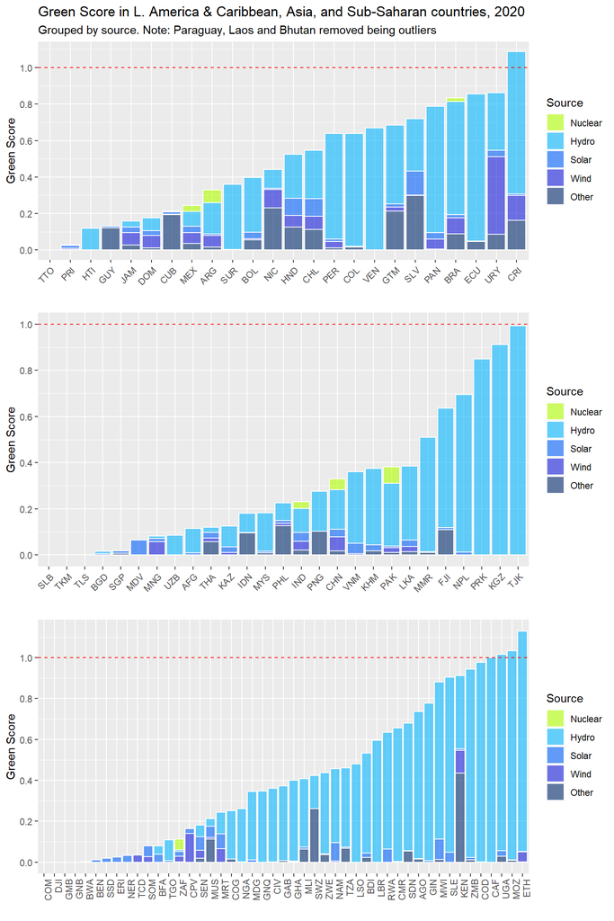

```r
# Creation of the plot for Latin America & Caribbean
gg1 = ggplot(filter(place, tag == "latin", iso_code != "PRY"),
       aes(x = reorder(iso_code, value), y = value, fill = Source)) +
  geom_bar(position = "stack", stat = "identity", alpha = 0.6, colour = "white") +
  scale_fill_manual(values = c("#B2FF00", "#05B6FF", "#0060FA", "#141BDB", "#00296B")) +
    scale_y_continuous(breaks = seq(0, 1.2, by = 0.2)) +
  geom_hline(yintercept = 1, linetype = "dashed", color = "red") +
  labs(title = "Green Score in L. America & Caribbean, Asia, and Sub-Saharan countries, 2020",
       subtitle = "Grouped by source. Note: Paraguay, Laos and Bhutan removed being outliers",
       x = "",
       y = "Green Score") +
  theme(axis.text.x = element_text(angle = 45, hjust = 1))

# Creation of the plot for the Asian countries
gg2 = ggplot(filter(place, tag == "asian", iso_code != "LAO", iso_code != "BTN"),
       aes(x = reorder(iso_code, value), y = value, fill = Source)) +
  geom_bar(position = "stack", stat = "identity", alpha = 0.6, colour = "white") +
  scale_fill_manual(values = c("#B2FF00", "#05B6FF", "#0060FA", "#141BDB", "#00296B")) +
    scale_y_continuous(breaks = seq(0, 1, by = 0.2)) +
  geom_hline(yintercept = 1, linetype = "dashed", color = "red") +
  labs(x = "",
       y = "Green Score") +
  theme(axis.text.x = element_text(angle = 45, hjust = 1))

# creation of the plot for the Sub-Saharan Africa
gg3 = ggplot(filter(place, tag == "sub_african"),
       aes(x = reorder(iso_code, value), y = value, fill = Source)) +
  geom_bar(position = "stack", stat = "identity", alpha = 0.6, colour = "white") +
  scale_fill_manual(values = c("#B2FF00", "#05B6FF", "#0060FA", "#141BDB", "#00296B")) +
    scale_y_continuous(breaks = seq(0, 1.2, by = 0.2)) +
  geom_hline(yintercept = 1, linetype = "dashed", color = "red") +
  labs(x = "",
       y = "Green Score") +
  theme(axis.text.x = element_text(angle = 90, hjust = 1))

# Visualization of the plots
grid.arrange(gg1, gg2, gg3, ncol=1)
```

We grouped the findings for Latin America & Caribbean, Asia, and Sub-Saharan countries because their electricity mixes are similar and mainly driven by hydropower.

The **best-performing** countries in each macroregion are Costa Rica, Uruguay, and Ecuador for Latin America & Caribbean; Tajikistan, Kyrgyzstan, and North Korea for Asia; Ethiopia, Mozambique, and Uganda for Sub-Saharan Africa. Instead, the countries with the lowest Green Score are respectively: Haiti, Porto Rico, and Trinidad & Tobago; Timor Est, Turkmenistan, and Solomon Islands; Botswana, Guinea-Bissau, Gambia, Djibouti, and Comoros (tied with totally fossil-dependent electricity generation).

Here are the other main observations:

1. some Latin American and Caribbean countries also have significant production from other sources, notably **Uruguay**, which mainly produces electricity through wind power;
2. **Kenya** is the only Sub-Saharan country with a good Green Score that generates significantly from non-hydropower sources. The reason is that the country exploits the incredibly cost-effective geothermic capacity of the Rift Valley. [16]

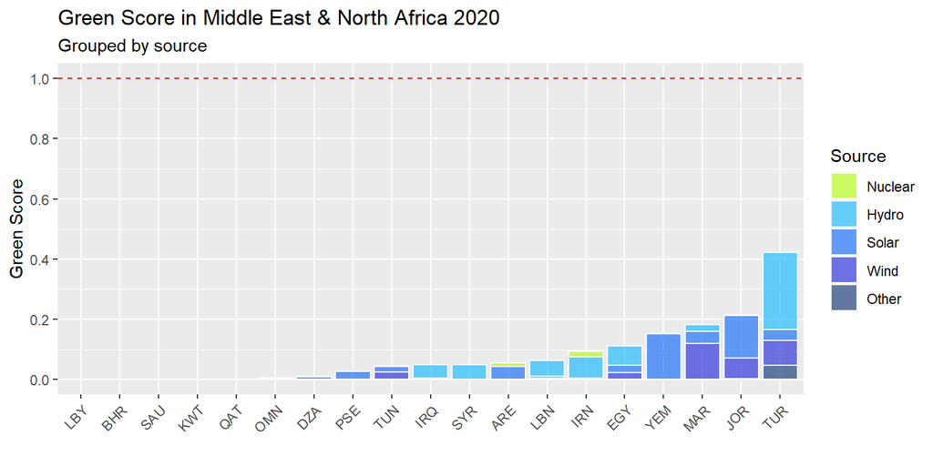

```r
# Creation of the plot for the North African & Middle-East countries
ggplot(filter(place, tag == "middle_east"),
       aes(x = reorder(iso_code, value), y = value, fill = Source)) +
  geom_bar(position = "stack", stat = "identity", alpha = 0.6, colour = "white") +
  scale_fill_manual(values = c("#B2FF00", "#05B6FF", "#0060FA", "#141BDB", "#00296B")) +
    scale_y_continuous(breaks = seq(0, 1, by = 0.2)) +
  geom_hline(yintercept = 1, linetype = "dashed", color = "red") +
  labs(title = "Green Score in Middle East & North Africa 2020",
       subtitle = "Grouped by source",
       x = "",
       y = "Green Score") +
  theme(axis.text.x = element_text(angle = 45, hjust = 1))
```

We conclude the descriptive analyses by examining the performance of Northern African and Middle East countries. Consistently with the findings in paragraph 4.3, the barplot shows that all the countries fail to reach a good performance: the best performing one, **Turkey**, has a Green Score smaller than 0.5. As the following table shows, this is mainly due to their large availability of oil and gas.

```r
# Creation of a dataset containing per capita average fossil reserves in Middle-East
# and Northern African countries VS the rest of the world
place = filter(main, year == 2020, tag == "middle_east") %>%
  select(population, oil_reserves_2020, gas_reserves) %>%
  mutate_all(~replace_na(.,0)) %>%
  summarize(oil_reserves_2020 = round(mean(oil_reserves_2020 / population),2),
            gas_reserves = round(mean(gas_reserves / population),2))

place2 = filter(main, year == 2020, tag != "middle_east") %>%
  select(population, oil_reserves_2020, gas_reserves) %>%
  mutate_all(~replace_na(.,0)) %>%
  summarize(oil_reserves_2020 = round(mean(oil_reserves_2020 / population),2),
            gas_reserves = round(mean(gas_reserves / population),2))

place = rbind(place, place2)
place = cbind(c("Middle East & North Africa", "Other countries"), place)
colnames(place) = c("Macroregion", "Oil (2020)", "Gas (2020)")
kable(place, caption = "Per capita reserves of fossil electricity sources")
```

Per capita reserves of fossil electricity sources

| Macroregion | Oil (2020) | Gas (2020) |
| --- | --- | --- |
| Middle East & North Africa | 469.81 | 583180.3 |
| Other countries | 18.40 | 22920.9 |

# Chapter 5: Modeling

## 5.1 Initial data preparation for Modeling

To build the models, we start by preparing the data for it.

We take the dataset transformed in the exploratory analysis (pro capita in million inhabitants and logarithm transformations). We add a column containing the **tag** variable to this dataset, as done in the descriptive analysis. This time we insert both the normal feature and a dummy version of it. The reason is that linear models and stepwise selection work with the first one, while lasso and ridge models need the second one.

We then filter the dataset by considering only units that year variables between 2000 and 2019 (even if this passage might be redundant with the next), and then we get a subset that contains only complete cases of the dataset.

```r
#adding tags here as well
mainlog = cbind(mainlog, tag)
mainlog = cbind(mainlog, model.matrix(~-1+tag, data=mainlog))
#keep only years between 2000 and 2019
mainlogm = mainlog[mainlog$year %in% 2000:2019,]

mainlogm=mainlogm[complete.cases(mainlogm),]
```

## 5.2 Functions definition

In order to make multiple models, we create tailored functions to make the code less repetitive.

We first define two simple functions to transform the variables: one applies min-max normalization; the other contains the logit function, modified to avoids infinite values (since our data lies in the interval [0,1], 0 and 1 included)

We also define what columns we will later apply the functions to (in this case all numerical columns except **year**).

```r
#normalizing columns
normalize <- function(x) {
  return((x- min(x)) /(max(x)-min(x)))
}

#applying logit to normalized column
logify <- function(x){
  return(qlogis((x/1.00001)+0.000005))
}

normcols=c(4:46)
```

In the following step, we define the function *selectvar_nl*, which allows us to select which columns to include in the model as independent variables.

The arguments are all boolean except the last one:

- *Bi*, identifies whether we want to include *Energy dataset*’s variables which regard the specific energy sources electricity production;
- *Bt*, identifies whether we want to include **tag**;
- *By*, identifies whether the functions defined above to normalize and apply the logit function is applied over the column grouped by year, or on the whole column;
- *Bl*, identifies whether to apply the logit function or not (normalization is always applied);
- *mlm*, the dataset to be transformed.

The function returns a list with two items: the modified dataset and a sub-list with the names of the variables used.

```r
selectvar_nl <- function(Bi=Bindepsource, Bt=Btag, By=Byearwise, Bl=Blogify, mlm=mainlogm){
  if (By){
    #year-wise normalization
    for (i in unique(mlm$year)){
      mlm[mlm$year==i,normcols] <- lapply(mlm[mlm$year==i,normcols], normalize)
    }
  } else {
    #overall normalization
    mlm[normcols] <- lapply(mlm[normcols], normalize)
  }
  #normalize year
  mlm["year"] <- lapply(mlm["year"], normalize)

  if (Bl){
    if(By){
      #year-wise logify
      for (i in unique(mlm$year)){
        mlm[mlm$year==i,normcols] <- lapply(mlm[mlm$year==i,normcols], logify)
      }
    } else {
      #overall logify
      mlm[normcols] <- lapply(mlm[normcols], logify)
    }
    #logify year
    mlm["year"] <- lapply(mlm["year"], logify)
  }

  if (Bi){
    independent = colnames(mlm)[c(2,4,6,14,18,23,25,28,33,35,37,38,39,41,42,43,44,45,46)]
  } else {
    independent = colnames(mlm)[c(2,4,37,38,39,41,42,43,44,45,46)]
  }
  if (Bt){
    independent = append(independent, colnames(mlm[47]))
  }
  return(list("mlm"=mlm, "ind"=independent))
}
```

Next, we define the function *setup_lr*, which has four arguments:

- *mlm*, the dataset used for the model;
- *dep*, the name of the model’s dependent variable in the model;
- *ind*, a list containing the model’s independent variables names;
- *Bt*, boolean, whether the model should have **tag** as an independent variable.

The function returns a list of two elements:

1. the list of values of the dependent variable;
2. a matrix containing the values of the variables used as independent variables (the transformation to matrix is needed to use the function that create lasso and ridge models).

```r
#Setup for Lasso and Ridge
setup_lr = function(mlm=model_data, dep=dependent, ind=independent, Bt=Btag){
  y = mlm[,dep]
  if (Bt){
    x = data.matrix(select(mlm,c(head(ind,-1),tail(colnames(mlm),6))))
  } else {
    x = data.matrix(select(mlm,ind))
  }
  return(list("y"=y, "x"=x))
}
```

Then we define the function *rs_models*, which gets the same arguments as *setup_lr*.

The function runs the linear model with the dependent and independent variables passed in the arguments; then performs a stepwise variables selection using BIC as criterion (k=log(n)).

Subsequently, it calls the function *setup_lr* to get the matrices to run *glmnet*; it uses cross-validation to find the best lambda and then uses it to build the elastic-net models (lasso with alpha = 1, ridge with alpha=0).

Finally, the function returns a list of 5 sub-lists:

- *rs*, which contains the R squared of each model obtained (linear, stepwise, lasso, and ridge);
- *coeff_lm*, which contains the coefficients in the linear model;
- *coeff_sm*, which contains the coefficients in the linear model after stepwise variable selection;
- *coeff_lasso*, which contains the coefficients in the lasso model;
- *coeff_ridge*, which contains the coefficients in the ridge model.

All the coefficients’ variables are ordered by their descending absolute value.

```r
rs_models = function(mlm=model_data, dep=dependent, ind=independent, Bt=Btag){
  my_formula <- as.formula(paste(paste(dep), " ~ ", paste(ind, collapse = " + ")))
  model <- lm(my_formula, mlm)
  step_model=step(model,direction=c("both"), trace=FALSE, k=log(nrow(mainlogm)))
  xy = setup_lr(mlm, dep, ind, Bt)
  x = xy$x
  y = xy$y
  cv_model = cv.glmnet(x, y, alpha = 1)
  best_lasso = glmnet(x, y, alpha = 1, lambda = cv_model$lambda.min)
  cv_model = cv.glmnet(x, y, alpha = 0)
  best_ridge = glmnet(x, y, alpha = 0, lambda = cv_model$lambda.min)
  names_coeff_lasso = dimnames(coef(best_lasso))[[1]][which(coef(best_lasso) != 0)]
  names_coeff_ridge = dimnames(coef(best_ridge))[[1]][which(coef(best_ridge) != 0)]
  values_coeff_lasso = coef(best_lasso)[which(coef(best_lasso) != 0)]
  values_coeff_ridge = coef(best_ridge)[which(coef(best_ridge) != 0)]
  coeff_lasso = setNames(values_coeff_lasso, names_coeff_lasso)
  coeff_ridge = setNames(values_coeff_ridge, names_coeff_ridge)
  coeff_lm = model$coefficients
  coeff_sm = step_model$coefficients
  rsq = c(summary(model)$r.squared, summary(step_model)$r.squared,
          best_lasso$dev.ratio, best_ridge$dev.ratio)
  return(list("rs" = setNames(rsq, c("lm","sm","lasso","ridge")),
              "coeff_lm" = coeff_lm[order(-abs(sapply(coeff_lm,'[[',1)))],
              "coeff_sm" = coeff_sm[order(-abs(sapply(coeff_sm,'[[',1)))],
              "coeff_lasso" = coeff_lasso[order(-abs(sapply(coeff_lasso,'[[',1)))],
              "coeff_ridge" = coeff_ridge[order(-abs(sapply(coeff_ridge,'[[',1)))]))
}
```

The last function defined is *do_models*.

It only has one argument, *depen*, which is the name of the dependent variable we want to have in the model.

The function builds a data frame with eight columns: the first four contain the boolean values used as arguments by *selectvar_nl*; the last four are the values returned by *rs_models* in the *rs item* (the R squared value for the four models).

For each possible combination of True-False values requested as input by *selectvar_nl*, the function calls *select var* and then *rs_models*, giving as arguments the data and list of independent variables returned by *selectvar_nl*; the value are then inserted in the data frame.

The function then returns which arguments are to be passed to get the best models (to be precise, the model with the best R squared for the linear with stepwise selection) and its scores, together with the coefficients of the stepwise selection model with such arguments.

Then the same is returned again, but this time only considering the models that do not contain the energy source data as independent variables.

Finally, the whole data frame is returned.

This approach allows us to compare the performance of all different models to learn how to build the best model for the data.

```r
do_models <- function(depen = dependent){
  dependent = depen

  results_df <- data.frame(Bindepsource = logical(), Btag = logical(),
                           Byearwise = logical(), Blogify = logical(),
                           lm = numeric(), sm = numeric(),
                           lasso = numeric(), ridge = numeric())

  for (i in c(TRUE, FALSE)) {
    for (j in c(TRUE, FALSE)) {
      for (k in c(TRUE, FALSE)) {
        for (l in c(TRUE, FALSE)) {
          tmp = selectvar_nl(Bi=i, Bt=j, By=k, Bl=l)
          model_data = tmp$mlm
          independent = tmp$ind
          results = rs_models(mlm=model_data, dep=dependent, ind=independent, Bt=j)
          results_df <- rbind(results_df, data.frame(Bindepsource = i,
                                                     Btag = j,
                                                     Byearwise = k,
                                                     Blogify = l,
                                                     lm = results$rs['lm'],
                                                     sm = results$rs['sm'],
                                                     lasso = results$rs['lasso'],
                                                     ridge = results$rs['ridge']))
        }
      }
    }
  }

  max_row <- results_df[which.max(results_df$sm), ]

  max_row_nind <- results_df[which.max(results_df[9:16,]$sm)+8, ]

  tmp = selectvar_nl(Bi=max_row$Bindepsource, Bt=max_row$Btag,
                     By=max_row$Byearwise, Bl=max_row$Blogify)
  model_data = tmp$mlm
  independent = tmp$ind
  results = rs_models(mlm=model_data, dep=dependent,
                      ind=independent, Bt=max_row$Btag)

  tmp = selectvar_nl(Bi=max_row_nind$Bindepsource, Bt=max_row_nind$Btag,
                     By=max_row_nind$Byearwise, Bl=max_row_nind$Blogify)
  model_data = tmp$mlm
  independent = tmp$ind
  results_nind = rs_models(mlm=model_data, dep=dependent,
                           ind=independent, Bt=max_row_nind$Btag)

  print(paste("Models for the variable:", dependent))
  print("")
  print(kable(as.data.frame(max_row), caption = "Best performing models"))
  print(kable(as.data.frame(results$coeff_sm), caption = "Coefficients for best stepwise lm"))
  print(kable(as.data.frame(max_row_nind),
              caption = "Best performing models with only external data"))
  print(kable(as.data.frame(results_nind$coeff_sm),
              caption = "Coefficients for best stepwise lm with only external data"))
  print(kable(results_df, caption = "Performance on all models"))

}
```

## 5.3 Obtaining Models

The last step involves only calling the **do_models** function, passing the dependent variable.

Ten dependent variables are passed, all included in the initial *Energy dataset*: *carbon intensity of electricity*, *greenhouse gas emissions*, *share of electricity of fossil electricity*, and the share of electricity of all low-carbon electricity sources.

Notice that for the last eight features, we will mainly focus on analyzing the model with only external independent variables since when analyzing the share of electricity of a given source, the electricity production of such source has a high correlation, giving us a high R squared, but only trivial results.

It is crucial to notice also that, when applying the logit function, the numerical variables in the dataset are all distributed between roughly -12 and +12, so their coefficients are comparable among them but are not directly comparable to the coefficients for the tag variables; instead, when the logit function is not applied, they can be directly compared.

GDP and HDI, which are significantly correlated, often appear with similar but opposite coefficients, which indicates rich countries where investment in human development and freedom is not as high when GDP has a positive coefficient and HDI a negative one, and the opposite when GDP is negative and HDI positive.

### 5.3.1 Carbon intensity of electricity

```r
do_models(depen="carbon_intensity_elec")
```

[output not shown]

```
## [1] "Models for the variable: carbon_intensity_elec"
## [1] ""
##
##
## Table: Best performing models
##
## |    |Bindepsource |Btag |Byearwise |Blogify |        lm|        sm|     lasso|     ridge|
## |:---|:------------|:----|:---------|:-------|---------:|---------:|---------:|---------:|
## |lm2 |TRUE         |TRUE |FALSE     |TRUE    | 0.5345208| 0.5312796| 0.5343709| 0.5306843|
##
##
## Table: Coefficients for best stepwise lm
##
## |                    | results$coeff_sm|
## |:-------------------|----------------:|
## |(Intercept)         |       -0.6665385|
## |tagdeveloped        |       -0.6303496|
## |tageast_europe      |        0.4009654|
## |gdp                 |        0.3890607|
## |tagsub_african      |       -0.3671303|
## |hdi                 |       -0.2808178|
## |hydro_electricity   |       -0.2599964|
## |taglatin            |       -0.2274012|
## |oil_electricity     |        0.1660544|
## |coal_electricity    |        0.1180649|
## |land_area           |        0.1062362|
## |nuclear_electricity |       -0.0779265|
## |agri_land_rate      |        0.0735105|
## |urbaniz_rate        |        0.0642560|
## |coal_reserves_2021  |        0.0250738|
## |tagmiddle_east      |       -0.0152201|
##
##
## Table: Best performing models with only external data
##
## |     |Bindepsource |Btag |Byearwise |Blogify |       lm|        sm|     lasso|     ridge|
## |:----|:------------|:----|:---------|:-------|--------:|---------:|---------:|---------:|
## |lm11 |FALSE        |TRUE |FALSE     |FALSE   | 0.260983| 0.2595082| 0.2609555| 0.2590556|
##
##
```

[output cut: 25 more lines]

```
## |lm1  |TRUE         |TRUE  |TRUE      |FALSE   | 0.4671707| 0.4650698| 0.4671266| 0.4635382|
## |lm2  |TRUE         |TRUE  |FALSE     |TRUE    | 0.5345208| 0.5312796| 0.5343709| 0.5306843|
## |lm3  |TRUE         |TRUE  |FALSE     |FALSE   | 0.4832769| 0.4816792| 0.4832405| 0.4786653|
## |lm4  |TRUE         |FALSE |TRUE      |TRUE    | 0.4896714| 0.4879791| 0.4890934| 0.4872723|
## |lm5  |TRUE         |FALSE |TRUE      |FALSE   | 0.4265291| 0.4245340| 0.4265070| 0.4241049|
## |lm6  |TRUE         |FALSE |FALSE     |TRUE    | 0.5088925| 0.5039002| 0.5088646| 0.5058196|
## |lm7  |TRUE         |FALSE |FALSE     |FALSE   | 0.4413045| 0.4386144| 0.4412801| 0.4387359|
## |lm8  |FALSE        |TRUE  |TRUE      |TRUE    | 0.1550579| 0.1522984| 0.1550002| 0.1548772|
## |lm9  |FALSE        |TRUE  |TRUE      |FALSE   | 0.2501506| 0.2500491| 0.2499998| 0.2488066|
## |lm10 |FALSE        |TRUE  |FALSE     |TRUE    | 0.1782024| 0.1750655| 0.1778535| 0.1770559|
## |lm11 |FALSE        |TRUE  |FALSE     |FALSE   | 0.2609830| 0.2595082| 0.2609555| 0.2590556|
## |lm12 |FALSE        |FALSE |TRUE      |TRUE    | 0.1114156| 0.1065295| 0.1114116| 0.1112808|
## |lm13 |FALSE        |FALSE |TRUE      |FALSE   | 0.2077355| 0.2077320| 0.2076887| 0.2069483|
## |lm14 |FALSE        |FALSE |FALSE     |TRUE    | 0.1418332| 0.1358737| 0.1410223| 0.1406853|
## |lm15 |FALSE        |FALSE |FALSE     |FALSE   | 0.2203351| 0.2189623| 0.2203224| 0.2192978|
```

Performance on the carbon intensity of electricity is relatively low, even with the energy source variables in the model, at ~0.53.

GDP and HDI have opposite weights, indicating that high carbon intensity is related to rich countries with lower HDI. However, the HDI coefficient is only ~.75 of the GDP, indicating that richer countries’ inhabitants still pollute more than poorer countries.

The tag for Eastern Europe is positive, while the others are negative, with the developed countries tag having a high coefficient (which also balances out with the score for GDP), relating to the fact that people in many developed countries pollute less, thanks to the high share of renewables in their electricity mix.

As expected, coefficients related to the source of electricity are positive for fossil sources and negative for hydro and nuclear, solar, and wind. Therefore, they are instead not kept in the stepwise model.

Regarding the model excluding source data, the performance is ~0.26, and does not use logit on the data.

Now population and land area have high negative coefficients, indicating that populations in smaller but significantly less populated countries pollute way more.

The coefficients on the tags are different, with Eastern countries having a negative coefficient while middle-east has a positive coefficient. This also relates to the influence of population and land area above: Eastern European countries tend to be extensive and populated, while in the middle east; thus, we probably have outliers of small countries that pollute a lot due to oil production.

### 5.3.2 Greenhouse gas emissions

```r
do_models(depen="greenhouse_gas_emissions")
```

```
## [1] "Models for the variable: greenhouse_gas_emissions"
## [1] ""
##
##
## Table: Best performing models
##
## |    |Bindepsource |Btag |Byearwise |Blogify |        lm|        sm|    lasso|     ridge|
## |:---|:------------|:----|:---------|:-------|---------:|---------:|--------:|---------:|
## |lm3 |TRUE         |TRUE |FALSE     |FALSE   | 0.9997319| 0.9997304| 0.999026| 0.9900342|
##
##
## Table: Coefficients for best stepwise lm
##
## |                            | results$coeff_sm|
## |:---------------------------|----------------:|
## |gas_electricity             |        0.9969829|
## |coal_electricity            |        0.7230451|
## |oil_electricity             |        0.6358749|
## |hydro_electricity           |        0.0912293|
## |other_renewable_electricity |        0.0759251|
## |nuclear_electricity         |        0.0218374|
## |wind_electricity            |        0.0177594|
## |hdi                         |        0.0029589|
## |land_area                   |        0.0019338|
## |(Intercept)                 |       -0.0013812|
## |coal_reserves_2021          |       -0.0012207|
## |urbaniz_rate                |       -0.0011272|
## |tageast_europe              |       -0.0008518|
## |agri_land_rate              |       -0.0007515|
## |tagmiddle_east              |       -0.0005090|
## |tagdeveloped                |        0.0004676|
## |tagsub_african              |        0.0003568|
## |taglatin                    |        0.0001462|
##
##
## Table: Best performing models with only external data
##
## |     |Bindepsource |Btag |Byearwise |Blogify |        lm|        sm|     lasso|     ridge|
## |:----|:------------|:----|:---------|:-------|---------:|---------:|---------:|---------:|
## |lm10 |FALSE        |TRUE |FALSE     |TRUE    | 0.7778692| 0.7776551| 0.7778267| 0.7748152|
```

[output cut: 28 more lines]

```
## |lm1  |TRUE         |TRUE  |TRUE      |FALSE   | 0.9601086| 0.9600636| 0.9600697| 0.9532482|
## |lm2  |TRUE         |TRUE  |FALSE     |TRUE    | 0.8426872| 0.8424920| 0.8426383| 0.8395067|
## |lm3  |TRUE         |TRUE  |FALSE     |FALSE   | 0.9997319| 0.9997304| 0.9990260| 0.9900342|
## |lm4  |TRUE         |FALSE |TRUE      |TRUE    | 0.7256124| 0.7245526| 0.7255821| 0.7230750|
## |lm5  |TRUE         |FALSE |TRUE      |FALSE   | 0.9578822| 0.9577008| 0.9578303| 0.9506877|
## |lm6  |TRUE         |FALSE |FALSE     |TRUE    | 0.8156265| 0.8153165| 0.8155867| 0.8126405|
## |lm7  |TRUE         |FALSE |FALSE     |FALSE   | 0.9997277| 0.9997252| 0.9990152| 0.9906047|
## |lm8  |FALSE        |TRUE  |TRUE      |TRUE    | 0.6470084| 0.6461660| 0.6469782| 0.6458597|
## |lm9  |FALSE        |TRUE  |TRUE      |FALSE   | 0.6217946| 0.6200317| 0.6217469| 0.6135361|
## |lm10 |FALSE        |TRUE  |FALSE     |TRUE    | 0.7778692| 0.7776551| 0.7778267| 0.7748152|
## |lm11 |FALSE        |TRUE  |FALSE     |FALSE   | 0.6209938| 0.6196816| 0.6209481| 0.6129978|
## |lm12 |FALSE        |FALSE |TRUE      |TRUE    | 0.5845940| 0.5827457| 0.5845649| 0.5831239|
## |lm13 |FALSE        |FALSE |TRUE      |FALSE   | 0.5748852| 0.5748006| 0.5748509| 0.5663684|
## |lm14 |FALSE        |FALSE |FALSE     |TRUE    | 0.7319622| 0.7311077| 0.7319295| 0.7300817|
## |lm15 |FALSE        |FALSE |FALSE     |FALSE   | 0.5724844| 0.5724219| 0.5724514| 0.5639957|
```

Greenhouse gas emission models have a very high R squared, with the best model ~1.

Gas, coal, and oil electricity explain most of the independent feature. However, curiously also hydro, other renewables, and nuclear have a positive correlation.

The model without sources still has a very high R squared ~0.77.

In this case, there is a significant influence of GDP with positive coefficients, and HDI also has a positive coefficient, indicating greenhouse gas emissions are very correlated to rich countries,

The tags are positive for the Middle East and Eastern Europe and negative for the others, especially Sub-Saharan Africa and developed countries.

### 5.3.3 Hydro share of electricity

```r
do_models(depen="hydro_share_elec")
```

```
## [1] "Models for the variable: hydro_share_elec"
## [1] ""
##
##
## Table: Best performing models
##
## |    |Bindepsource |Btag |Byearwise |Blogify |        lm|        sm|     lasso|     ridge|
## |:---|:------------|:----|:---------|:-------|---------:|---------:|---------:|---------:|
## |lm2 |TRUE         |TRUE |FALSE     |TRUE    | 0.8722087| 0.8701415| 0.8721662| 0.8631823|
##
##
## Table: Coefficients for best stepwise lm
##
## |                            | results$coeff_sm|
## |:---------------------------|----------------:|
## |(Intercept)                 |        4.0400231|
## |hydro_electricity           |        1.5816282|
## |tageast_europe              |       -1.3485628|
## |tagsub_african              |        0.9492310|
## |gdp                         |       -0.7860944|
## |tagmiddle_east              |       -0.6490157|
## |land_area                   |       -0.5314326|
## |taglatin                    |        0.4566842|
## |oil_electricity             |       -0.2621500|
## |urbaniz_rate                |       -0.2119081|
## |other_renewable_electricity |       -0.1684825|
## |population                  |        0.1617658|
## |coal_electricity            |       -0.1481847|
## |wind_electricity            |        0.0601382|
## |tagdeveloped                |       -0.0107972|
##
##
## Table: Best performing models with only external data
##
## |     |Bindepsource |Btag |Byearwise |Blogify |        lm|        sm|     lasso|     ridge|
## |:----|:------------|:----|:---------|:-------|---------:|---------:|---------:|---------:|
## |lm11 |FALSE        |TRUE |FALSE     |FALSE   | 0.3396587| 0.3395835| 0.3396372| 0.3330256|
##
##
## Table: Coefficients for best stepwise lm with only external data
```

[output cut: 26 more lines]

```
## |lm1  |TRUE         |TRUE  |TRUE      |FALSE   | 0.4736208| 0.4729328| 0.4735846| 0.4684607|
## |lm2  |TRUE         |TRUE  |FALSE     |TRUE    | 0.8722087| 0.8701415| 0.8721662| 0.8631823|
## |lm3  |TRUE         |TRUE  |FALSE     |FALSE   | 0.4946946| 0.4941418| 0.4946709| 0.4886738|
## |lm4  |TRUE         |FALSE |TRUE      |TRUE    | 0.8046176| 0.8043559| 0.8045764| 0.7965902|
## |lm5  |TRUE         |FALSE |TRUE      |FALSE   | 0.4228089| 0.4204118| 0.4227770| 0.4202896|
## |lm6  |TRUE         |FALSE |FALSE     |TRUE    | 0.8654082| 0.8645582| 0.8653555| 0.8569189|
## |lm7  |TRUE         |FALSE |FALSE     |FALSE   | 0.4458070| 0.4437792| 0.4457821| 0.4431344|
## |lm8  |FALSE        |TRUE  |TRUE      |TRUE    | 0.2400780| 0.2381664| 0.2400617| 0.2397156|
## |lm9  |FALSE        |TRUE  |TRUE      |FALSE   | 0.3263678| 0.3257687| 0.3263466| 0.3211063|
## |lm10 |FALSE        |TRUE  |FALSE     |TRUE    | 0.2964711| 0.2945068| 0.2964064| 0.2949013|
## |lm11 |FALSE        |TRUE  |FALSE     |FALSE   | 0.3396587| 0.3395835| 0.3396372| 0.3330256|
## |lm12 |FALSE        |FALSE |TRUE      |TRUE    | 0.1990178| 0.1989606| 0.1988393| 0.1987068|
## |lm13 |FALSE        |FALSE |TRUE      |FALSE   | 0.2697632| 0.2691073| 0.2697512| 0.2677978|
## |lm14 |FALSE        |FALSE |FALSE     |TRUE    | 0.2512429| 0.2493177| 0.2510188| 0.2494011|
## |lm15 |FALSE        |FALSE |FALSE     |FALSE   | 0.2829128| 0.2824542| 0.2828892| 0.2805562|
```

Hydroelectricity is obviously a good indicator when sources are in the model. However, GDP and land area are also very influential, which might make us think that this clean energy source is also easily accessible to poorer and smaller countries; nonetheless, these are just an indication of total electricity production (especially regarding GDP: richer countries use more electricity pro capita).

In fact, the model excluding sources, land area, and population has negative coefficients, with HDI having a positive coefficient and GDP a negative one, indicating that for a high share of hydroelectricity, the country needs to be able to make sizeable investments.

In the model excluding source, we also have this time year included, with a small yet negative coefficient, indicating that the share of hydro in the electricity mix is getting lower each year if the other parameters are fixed.

### 5.3.4 Solar share of electricity

```r
do_models(depen="solar_share_elec")
```

```
## [1] "Models for the variable: solar_share_elec"
## [1] ""
##
##
## Table: Best performing models
##
## |    |Bindepsource |Btag |Byearwise |Blogify |        lm|        sm|     lasso|     ridge|
## |:---|:------------|:----|:---------|:-------|---------:|---------:|---------:|---------:|
## |lm2 |TRUE         |TRUE |FALSE     |TRUE    | 0.9532925| 0.9529513| 0.9532302| 0.9406927|
##
##
## Table: Coefficients for best stepwise lm
##
## |                    | results$coeff_sm|
## |:-------------------|----------------:|
## |solar_electricity   |        1.0521981|
## |tagdeveloped        |       -0.7459863|
## |tagmiddle_east      |       -0.2681365|
## |tagsub_african      |       -0.1778307|
## |taglatin            |       -0.1768368|
## |(Intercept)         |        0.1255167|
## |tageast_europe      |       -0.1223003|
## |population          |        0.1171737|
## |hdi                 |       -0.0956029|
## |agri_land_rate      |        0.0394254|
## |nuclear_electricity |       -0.0393302|
## |coal_reserves_2021  |       -0.0231408|
## |gas_electricity     |       -0.0212437|
##
##
## Table: Best performing models with only external data
##
## |     |Bindepsource |Btag |Byearwise |Blogify |        lm|        sm|     lasso|     ridge|
## |:----|:------------|:----|:---------|:-------|---------:|---------:|---------:|---------:|
## |lm10 |FALSE        |TRUE |FALSE     |TRUE    | 0.3338985| 0.3322466| 0.3338347| 0.3334057|
##
##
## Table: Coefficients for best stepwise lm with only external data
##
## |                      | results_nind$coeff_sm|
```

[output cut: 23 more lines]

```
## |lm1  |TRUE         |TRUE  |TRUE      |FALSE   | 0.6512108| 0.6473243| 0.6510877| 0.6462251|
## |lm2  |TRUE         |TRUE  |FALSE     |TRUE    | 0.9532925| 0.9529513| 0.9532302| 0.9406927|
## |lm3  |TRUE         |TRUE  |FALSE     |FALSE   | 0.6318986| 0.6262037| 0.6314946| 0.6272721|
## |lm4  |TRUE         |FALSE |TRUE      |TRUE    | 0.9074616| 0.9074010| 0.9073873| 0.8969142|
## |lm5  |TRUE         |FALSE |TRUE      |FALSE   | 0.6499696| 0.6473243| 0.6498094| 0.6450456|
## |lm6  |TRUE         |FALSE |FALSE     |TRUE    | 0.9517905| 0.9514997| 0.9517403| 0.9395924|
## |lm7  |TRUE         |FALSE |FALSE     |FALSE   | 0.6285994| 0.6262037| 0.6280086| 0.6241299|
## |lm8  |FALSE        |TRUE  |TRUE      |TRUE    | 0.3250663| 0.3241064| 0.3249415| 0.3245504|
## |lm9  |FALSE        |TRUE  |TRUE      |FALSE   | 0.1853965| 0.1821087| 0.1832003| 0.1848927|
## |lm10 |FALSE        |TRUE  |FALSE     |TRUE    | 0.3338985| 0.3322466| 0.3338347| 0.3334057|
## |lm11 |FALSE        |TRUE  |FALSE     |FALSE   | 0.1776729| 0.1740659| 0.1775776| 0.1767252|
## |lm12 |FALSE        |FALSE |TRUE      |TRUE    | 0.2626138| 0.2625994| 0.2624692| 0.2622873|
## |lm13 |FALSE        |FALSE |TRUE      |FALSE   | 0.1444018| 0.1427092| 0.1443885| 0.1436379|
## |lm14 |FALSE        |FALSE |FALSE     |TRUE    | 0.3075653| 0.3056911| 0.3075516| 0.3071665|
## |lm15 |FALSE        |FALSE |FALSE     |FALSE   | 0.1468499| 0.1419095| 0.1468396| 0.1459880|
```

Regarding solar generation, the model with sources is trivial, with most of the share explained by solar electricity.

It is interesting to analyze the model excluding source, in which HDI, GDP, and population have positive scores, indicating solar is accessible mainly to more prosperous and highly populated countries.

Here year appears with a noticeable weight, indicating that solar energy has quickly developed over the last two decades.

### 5.3.5 Wind share of electricity

```r
do_models(depen="wind_share_elec")
```

```
## [1] "Models for the variable: wind_share_elec"
## [1] ""
##
##
## Table: Best performing models
##
## |    |Bindepsource |Btag |Byearwise |Blogify |        lm|        sm|     lasso|     ridge|
## |:---|:------------|:----|:---------|:-------|---------:|---------:|---------:|---------:|
## |lm2 |TRUE         |TRUE |FALSE     |TRUE    | 0.9844039| 0.9843127| 0.9843542| 0.9656907|
##
##
## Table: Coefficients for best stepwise lm
##
## |                    | results$coeff_sm|
## |:-------------------|----------------:|
## |tagdeveloped        |       -1.1416358|
## |wind_electricity    |        1.1100925|
## |(Intercept)         |        0.9686533|
## |tagsub_african      |       -0.2693459|
## |tageast_europe      |       -0.1501065|
## |hdi                 |       -0.1404808|
## |tagmiddle_east      |        0.0924604|
## |land_area           |       -0.0875162|
## |population          |        0.0869981|
## |gdp                 |        0.0626305|
## |nuclear_electricity |       -0.0224733|
## |gas_electricity     |       -0.0210091|
## |agri_land_rate      |        0.0182419|
## |hydro_electricity   |       -0.0118503|
## |oil_electricity     |       -0.0107341|
## |taglatin            |        0.0093200|
## |gas_reserves        |       -0.0068677|
##
##
## Table: Best performing models with only external data
##
## |     |Bindepsource |Btag |Byearwise |Blogify |        lm|        sm|     lasso|     ridge|
## |:----|:------------|:----|:---------|:-------|---------:|---------:|---------:|---------:|
## |lm10 |FALSE        |TRUE |FALSE     |TRUE    | 0.4903061| 0.4898799| 0.4902841| 0.4894546|
##
```

[output cut: 28 more lines]

```
## |lm1  |TRUE         |TRUE  |TRUE      |FALSE   | 0.8180183| 0.8150051| 0.8177586| 0.8091617|
## |lm2  |TRUE         |TRUE  |FALSE     |TRUE    | 0.9844039| 0.9843127| 0.9843542| 0.9656907|
## |lm3  |TRUE         |TRUE  |FALSE     |FALSE   | 0.7663574| 0.7638306| 0.7663231| 0.7590068|
## |lm4  |TRUE         |FALSE |TRUE      |TRUE    | 0.9737698| 0.9735686| 0.9736944| 0.9590652|
## |lm5  |TRUE         |FALSE |TRUE      |FALSE   | 0.8164373| 0.8150051| 0.8163838| 0.8083559|
## |lm6  |TRUE         |FALSE |FALSE     |TRUE    | 0.9790619| 0.9790006| 0.9790034| 0.9624837|
## |lm7  |TRUE         |FALSE |FALSE     |FALSE   | 0.7649547| 0.7638306| 0.7649251| 0.7582635|
## |lm8  |FALSE        |TRUE  |TRUE      |TRUE    | 0.4696318| 0.4681342| 0.4695865| 0.4686405|
## |lm9  |FALSE        |TRUE  |TRUE      |FALSE   | 0.2580726| 0.2565171| 0.2580216| 0.2565790|
## |lm10 |FALSE        |TRUE  |FALSE     |TRUE    | 0.4903061| 0.4898799| 0.4902841| 0.4894546|
## |lm11 |FALSE        |TRUE  |FALSE     |FALSE   | 0.2295707| 0.2246848| 0.2295570| 0.2284636|
## |lm12 |FALSE        |FALSE |TRUE      |TRUE    | 0.3626293| 0.3621573| 0.3626135| 0.3620319|
## |lm13 |FALSE        |FALSE |TRUE      |FALSE   | 0.1847001| 0.1804610| 0.1846845| 0.1835520|
## |lm14 |FALSE        |FALSE |FALSE     |TRUE    | 0.4486921| 0.4482159| 0.4486711| 0.4472531|
## |lm15 |FALSE        |FALSE |FALSE     |FALSE   | 0.1775404| 0.1751734| 0.1774952| 0.1766446|
```

Similarly, wind’s share of electricity generation is mainly explained by the electricity production from wind, so it is not worth spending time on the best model.

The model excluding sources has an R squared ~0.49 and behaves very similarly to solar share. The major difference is in the tag *sub-african*, which for obvious geographical reasons has a positive coefficient, yet here it has a negative one.

### 5.3.6 Other renewables share of electricity

```r
do_models(depen="other_renewables_share_elec")
```

```
## [1] "Models for the variable: other_renewables_share_elec"
## [1] ""
##
##
## Table: Best performing models
##
## |   |Bindepsource |Btag |Byearwise |Blogify |        lm|        sm|     lasso|     ridge|
## |:--|:------------|:----|:---------|:-------|---------:|---------:|---------:|---------:|
## |lm |TRUE         |TRUE |TRUE      |TRUE    | 0.9221327| 0.9214762| 0.9220544| 0.9062341|
##
##
## Table: Coefficients for best stepwise lm
##
## |                            | results$coeff_sm|
## |:---------------------------|----------------:|
## |(Intercept)                 |       -2.0156652|
## |tagdeveloped                |       -1.1702433|
## |other_renewable_electricity |        1.1096296|
## |tageast_europe              |        0.3979516|
## |taglatin                    |       -0.3697240|
## |population                  |       -0.1741052|
## |tagsub_african              |        0.1428462|
## |nuclear_electricity         |       -0.1076176|
## |land_area                   |        0.0767394|
## |coal_electricity            |       -0.0696384|
## |tagmiddle_east              |       -0.0580652|
## |coal_reserves_2021          |       -0.0562147|
## |urbaniz_rate                |       -0.0532090|
## |hydro_electricity           |       -0.0448959|
## |gas_reserves                |       -0.0326719|
## |year                        |        0.0250557|
##
##
## Table: Best performing models with only external data
##
## |     |Bindepsource |Btag |Byearwise |Blogify |        lm|        sm|     lasso|     ridge|
## |:----|:------------|:----|:---------|:-------|---------:|---------:|---------:|---------:|
## |lm10 |FALSE        |TRUE |FALSE     |TRUE    | 0.2600053| 0.2581676| 0.2598656| 0.2594965|
##
##
```

[output cut: 24 more lines]

```
## |lm1  |TRUE         |TRUE  |TRUE      |FALSE   | 0.5515052| 0.5480883| 0.5514682| 0.5431949|
## |lm2  |TRUE         |TRUE  |FALSE     |TRUE    | 0.9216102| 0.9210009| 0.9215478| 0.9036343|
## |lm3  |TRUE         |TRUE  |FALSE     |FALSE   | 0.5220947| 0.5186935| 0.5220570| 0.5142534|
## |lm4  |TRUE         |FALSE |TRUE      |TRUE    | 0.9150720| 0.9145832| 0.9149685| 0.9012033|
## |lm5  |TRUE         |FALSE |TRUE      |FALSE   | 0.5499624| 0.5480883| 0.5499310| 0.5420196|
## |lm6  |TRUE         |FALSE |FALSE     |TRUE    | 0.9152209| 0.9148620| 0.9151793| 0.8993687|
## |lm7  |TRUE         |FALSE |FALSE     |FALSE   | 0.5209920| 0.5186935| 0.5209588| 0.5130419|
## |lm8  |FALSE        |TRUE  |TRUE      |TRUE    | 0.2176780| 0.2112594| 0.2176680| 0.2175135|
## |lm9  |FALSE        |TRUE  |TRUE      |FALSE   | 0.1261415| 0.1151474| 0.1261311| 0.1252381|
## |lm10 |FALSE        |TRUE  |FALSE     |TRUE    | 0.2600053| 0.2581676| 0.2598656| 0.2594965|
## |lm11 |FALSE        |TRUE  |FALSE     |FALSE   | 0.1394144| 0.1267532| 0.1393994| 0.1387185|
## |lm12 |FALSE        |FALSE |TRUE      |TRUE    | 0.1355634| 0.1331777| 0.1355571| 0.1354489|
## |lm13 |FALSE        |FALSE |TRUE      |FALSE   | 0.1160682| 0.1151474| 0.1160610| 0.1148401|
## |lm14 |FALSE        |FALSE |FALSE     |TRUE    | 0.1928867| 0.1917813| 0.1928621| 0.1924009|
## |lm15 |FALSE        |FALSE |FALSE     |FALSE   | 0.1320864| 0.1267532| 0.1320680| 0.1309237|
```

Other renewables’ behavior is also very similar to solar. However, in the model without sources (which has the lowest score of ~0.26, indicating it is hard to explain it with our variables), we now see a high coefficient for Latin America and Caribbeans instead, indicating that this measure is also highly related to local availability and geography.

### 5.3.7 Nuclear share of electricity

```r
do_models(depen="nuclear_share_elec")
```

```
## [1] "Models for the variable: nuclear_share_elec"
## [1] ""
##
##
## Table: Best performing models
##
## |    |Bindepsource |Btag |Byearwise |Blogify |        lm|        sm|    lasso|     ridge|
## |:---|:------------|:----|:---------|:-------|---------:|---------:|--------:|---------:|
## |lm2 |TRUE         |TRUE |FALSE     |TRUE    | 0.9861162| 0.9859826| 0.986057| 0.9738284|
##
##
## Table: Coefficients for best stepwise lm
##
## |                    | results$coeff_sm|
## |:-------------------|----------------:|
## |(Intercept)         |        1.1275109|
## |nuclear_electricity |        1.0704264|
## |tagdeveloped        |       -0.3782303|
## |tagmiddle_east      |       -0.2109865|
## |tagsub_african      |       -0.1880907|
## |tageast_europe      |        0.1712895|
## |hdi                 |       -0.0884279|
## |population          |        0.0697808|
## |gdp                 |        0.0672300|
## |land_area           |       -0.0559275|
## |agri_land_rate      |        0.0546028|
## |coal_electricity    |       -0.0226589|
## |coal_reserves_2021  |        0.0155275|
## |gas_reserves        |        0.0088970|
## |taglatin            |       -0.0053640|
##
##
## Table: Best performing models with only external data
##
## |     |Bindepsource |Btag |Byearwise |Blogify |       lm|        sm|     lasso|     ridge|
## |:----|:------------|:----|:---------|:-------|--------:|---------:|---------:|---------:|
## |lm10 |FALSE        |TRUE |FALSE     |TRUE    | 0.459583| 0.4574956| 0.4595275| 0.4591493|
##
##
## Table: Coefficients for best stepwise lm with only external data
```

[output cut: 23 more lines]

```
## |lm1  |TRUE         |TRUE  |TRUE      |FALSE   | 0.8549568| 0.8541355| 0.8549163| 0.8471012|
## |lm2  |TRUE         |TRUE  |FALSE     |TRUE    | 0.9861162| 0.9859826| 0.9860570| 0.9738284|
## |lm3  |TRUE         |TRUE  |FALSE     |FALSE   | 0.8597170| 0.8590185| 0.8596738| 0.8520994|
## |lm4  |TRUE         |FALSE |TRUE      |TRUE    | 0.9495076| 0.9490532| 0.9494549| 0.9392815|
## |lm5  |TRUE         |FALSE |TRUE      |FALSE   | 0.8229483| 0.8224376| 0.8228979| 0.8143804|
## |lm6  |TRUE         |FALSE |FALSE     |TRUE    | 0.9848376| 0.9847507| 0.9847741| 0.9731689|
## |lm7  |TRUE         |FALSE |FALSE     |FALSE   | 0.8307860| 0.8296260| 0.8307399| 0.8225923|
## |lm8  |FALSE        |TRUE  |TRUE      |TRUE    | 0.4057491| 0.4033973| 0.4053289| 0.4053933|
## |lm9  |FALSE        |TRUE  |TRUE      |FALSE   | 0.3464401| 0.3417525| 0.3464212| 0.3443844|
## |lm10 |FALSE        |TRUE  |FALSE     |TRUE    | 0.4595830| 0.4574956| 0.4595275| 0.4591493|
## |lm11 |FALSE        |TRUE  |FALSE     |FALSE   | 0.3561215| 0.3545879| 0.3560973| 0.3545575|
## |lm12 |FALSE        |FALSE |TRUE      |TRUE    | 0.3171428| 0.3165326| 0.3165964| 0.3167390|
## |lm13 |FALSE        |FALSE |TRUE      |FALSE   | 0.2518207| 0.2482337| 0.2518084| 0.2513190|
## |lm14 |FALSE        |FALSE |FALSE     |TRUE    | 0.4036612| 0.4006403| 0.4036035| 0.4028174|
## |lm15 |FALSE        |FALSE |FALSE     |FALSE   | 0.2700016| 0.2665232| 0.2699678| 0.2691938|
```

Considering nuclear share as dependent, we focus on the model excluding sources, which has a score of ~0.46 for the best model.

The tags variable shows a high preference for nuclear mainly in Eastern Europe and developed countries.

Population and HDI are the leading positive indicators, indicating that also nuclear is mainly accessible to richer and more populated countries; also, there is a negative coefficient for land area, showing its energy production efficiency in terms of electricity produced compared to the area needed to operate the nuclear plants.

Year’s variable is also present in this model, this time with a negative coefficient, indicating that countries are progressively abandoning nuclear, or at least they stopped investing in it.

Uranium reserves have a positive coefficient, indicating they can be a reason to invest in nuclear energy. However, it is not very high, indicating it is not a main concern, probably because of the low amount of material needed to produce electricity from nuclear, which makes transporting the material a small cost without the need of building infrastructure for it.

### 5.3.8 Renewables, Low carbon and Fossil share of electricity

```r
do_models(depen="renewables_share_elec")
```

```
## [1] "Models for the variable: renewables_share_elec"
## [1] ""
##
##
## Table: Best performing models
##
## |    |Bindepsource |Btag |Byearwise |Blogify |        lm|        sm|     lasso|     ridge|
## |:---|:------------|:----|:---------|:-------|---------:|---------:|---------:|---------:|
## |lm2 |TRUE         |TRUE |FALSE     |TRUE    | 0.7924768| 0.7909105| 0.7923975| 0.7858865|
##
##
## Table: Coefficients for best stepwise lm
##
## |                            | results$coeff_sm|
## |:---------------------------|----------------:|
## |(Intercept)                 |        5.1854476|
## |hydro_electricity           |        1.3302253|
## |gdp                         |       -0.9694312|
## |tagsub_african              |        0.5898365|
## |tagdeveloped                |        0.5494048|
## |tagmiddle_east              |       -0.4992895|
## |tageast_europe              |       -0.4278137|
## |land_area                   |       -0.3815821|
## |oil_electricity             |       -0.3268700|
## |taglatin                    |        0.2620910|
## |coal_electricity            |       -0.1894783|
## |other_renewable_electricity |        0.1600416|
## |gas_electricity             |       -0.1410298|
## |wind_electricity            |        0.1380852|
## |solar_electricity           |        0.1122998|
## |nuclear_electricity         |       -0.0896496|
## |gas_reserves                |        0.0465484|
## |coal_reserves_2021          |       -0.0365110|
##
##
## Table: Best performing models with only external data
##
## |     |Bindepsource |Btag |Byearwise |Blogify |        lm|        sm|     lasso|     ridge|
## |:----|:------------|:----|:---------|:-------|---------:|---------:|---------:|---------:|
## |lm11 |FALSE        |TRUE |FALSE     |FALSE   | 0.3398832| 0.3393901| 0.3398481| 0.3357615|
```

[output cut: 28 more lines]

```
## |lm1  |TRUE         |TRUE  |TRUE      |FALSE   | 0.4872912| 0.4861149| 0.4872198| 0.4833779|
## |lm2  |TRUE         |TRUE  |FALSE     |TRUE    | 0.7924768| 0.7909105| 0.7923975| 0.7858865|
## |lm3  |TRUE         |TRUE  |FALSE     |FALSE   | 0.5006437| 0.4994569| 0.5005879| 0.4960226|
## |lm4  |TRUE         |FALSE |TRUE      |TRUE    | 0.7492522| 0.7473281| 0.7492046| 0.7435600|
## |lm5  |TRUE         |FALSE |TRUE      |FALSE   | 0.4295078| 0.4287511| 0.4294687| 0.4279092|
## |lm6  |TRUE         |FALSE |FALSE     |TRUE    | 0.7893778| 0.7886939| 0.7893315| 0.7828918|
## |lm7  |TRUE         |FALSE |FALSE     |FALSE   | 0.4439032| 0.4396907| 0.4438812| 0.4421156|
## |lm8  |FALSE        |TRUE  |TRUE      |TRUE    | 0.2244147| 0.2233488| 0.2243851| 0.2240558|
## |lm9  |FALSE        |TRUE  |TRUE      |FALSE   | 0.3301242| 0.3291873| 0.3300821| 0.3266750|
## |lm10 |FALSE        |TRUE  |FALSE     |TRUE    | 0.2801782| 0.2798356| 0.2797992| 0.2787673|
## |lm11 |FALSE        |TRUE  |FALSE     |FALSE   | 0.3398832| 0.3393901| 0.3398481| 0.3357615|
## |lm12 |FALSE        |FALSE |TRUE      |TRUE    | 0.1713937| 0.1698180| 0.1713865| 0.1711820|
## |lm13 |FALSE        |FALSE |TRUE      |FALSE   | 0.2597227| 0.2577533| 0.2597038| 0.2587265|
## |lm14 |FALSE        |FALSE |FALSE     |TRUE    | 0.2249855| 0.2239086| 0.2247445| 0.2234740|
## |lm15 |FALSE        |FALSE |FALSE     |FALSE   | 0.2703876| 0.2703417| 0.2703720| 0.2691814|
```

```r
do_models(depen="low_carbon_share_elec")
```

```
## [1] "Models for the variable: low_carbon_share_elec"
## [1] ""
##
##
## Table: Best performing models
##
## |    |Bindepsource |Btag |Byearwise |Blogify |        lm|        sm|     lasso|     ridge|
## |:---|:------------|:----|:---------|:-------|---------:|---------:|---------:|---------:|
## |lm2 |TRUE         |TRUE |FALSE     |TRUE    | 0.7906304| 0.7895204| 0.7904757| 0.7840845|
##
##
## Table: Coefficients for best stepwise lm
##
## |                            | results$coeff_sm|
## |:---------------------------|----------------:|
## |(Intercept)                 |        6.9463657|
## |hydro_electricity           |        1.3185006|
## |gdp                         |       -0.9436698|
## |tagdeveloped                |        0.5209017|
## |tagsub_african              |        0.5022337|
## |tagmiddle_east              |       -0.4534741|
## |tageast_europe              |       -0.4272291|
## |land_area                   |       -0.3731762|
## |oil_electricity             |       -0.3273684|
## |coal_electricity            |       -0.1897854|
## |other_renewable_electricity |        0.1577925|
## |taglatin                    |        0.1302026|
## |wind_electricity            |        0.1226428|
## |solar_electricity           |        0.1193776|
## |gas_electricity             |       -0.1143774|
## |nuclear_electricity         |        0.0893336|
## |year                        |       -0.0482198|
## |coal_reserves_2021          |       -0.0400540|
##
##
## Table: Best performing models with only external data
##
## |     |Bindepsource |Btag |Byearwise |Blogify |        lm|        sm|     lasso|     ridge|
## |:----|:------------|:----|:---------|:-------|---------:|---------:|---------:|---------:|
## |lm11 |FALSE        |TRUE |FALSE     |FALSE   | 0.3426829| 0.3403904| 0.3426524| 0.3391884|
```

[output cut: 28 more lines]

```
## |lm1  |TRUE         |TRUE  |TRUE      |FALSE   | 0.5033493| 0.5019087| 0.5033017| 0.5002793|
## |lm2  |TRUE         |TRUE  |FALSE     |TRUE    | 0.7906304| 0.7895204| 0.7904757| 0.7840845|
## |lm3  |TRUE         |TRUE  |FALSE     |FALSE   | 0.5183225| 0.5164649| 0.5182766| 0.5144857|
## |lm4  |TRUE         |FALSE |TRUE      |TRUE    | 0.7499102| 0.7479253| 0.7498747| 0.7444595|
## |lm5  |TRUE         |FALSE |TRUE      |FALSE   | 0.4460168| 0.4441488| 0.4459701| 0.4443492|
## |lm6  |TRUE         |FALSE |FALSE     |TRUE    | 0.7877550| 0.7864344| 0.7876444| 0.7814279|
## |lm7  |TRUE         |FALSE |FALSE     |FALSE   | 0.4612759| 0.4582377| 0.4612451| 0.4594244|
## |lm8  |FALSE        |TRUE  |TRUE      |TRUE    | 0.2494761| 0.2489060| 0.2494680| 0.2490676|
## |lm9  |FALSE        |TRUE  |TRUE      |FALSE   | 0.3301761| 0.3296410| 0.3301593| 0.3274576|
## |lm10 |FALSE        |TRUE  |FALSE     |TRUE    | 0.3037926| 0.3034158| 0.3034522| 0.3022777|
## |lm11 |FALSE        |TRUE  |FALSE     |FALSE   | 0.3426829| 0.3403904| 0.3426524| 0.3391884|
## |lm12 |FALSE        |FALSE |TRUE      |TRUE    | 0.1895932| 0.1885575| 0.1895851| 0.1893335|
## |lm13 |FALSE        |FALSE |TRUE      |FALSE   | 0.2557127| 0.2533985| 0.2556969| 0.2544855|
## |lm14 |FALSE        |FALSE |FALSE     |TRUE    | 0.2449189| 0.2407402| 0.2448879| 0.2431050|
## |lm15 |FALSE        |FALSE |FALSE     |FALSE   | 0.2712288| 0.2683122| 0.2712076| 0.2697490|
```

```r
do_models(depen="fossil_share_elec")
```

```
## [1] "Models for the variable: fossil_share_elec"
## [1] ""
##
##
## Table: Best performing models
##
## |    |Bindepsource |Btag |Byearwise |Blogify |        lm|        sm|     lasso|     ridge|
## |:---|:------------|:----|:---------|:-------|---------:|---------:|---------:|---------:|
## |lm2 |TRUE         |TRUE |FALSE     |TRUE    | 0.7906306| 0.7895206| 0.7904144| 0.7840847|
##
##
## Table: Coefficients for best stepwise lm
##
## |                            | results$coeff_sm|
## |:---------------------------|----------------:|
## |(Intercept)                 |       -6.9463806|
## |hydro_electricity           |       -1.3185018|
## |gdp                         |        0.9436708|
## |tagdeveloped                |       -0.5208989|
## |tagsub_african              |       -0.5022372|
## |tagmiddle_east              |        0.4534814|
## |tageast_europe              |        0.4272278|
## |land_area                   |        0.3731771|
## |oil_electricity             |        0.3273681|
## |coal_electricity            |        0.1897851|
## |other_renewable_electricity |       -0.1577927|
## |taglatin                    |       -0.1302043|
## |wind_electricity            |       -0.1226431|
## |solar_electricity           |       -0.1193779|
## |gas_electricity             |        0.1143771|
## |nuclear_electricity         |       -0.0893335|
## |year                        |        0.0482195|
## |coal_reserves_2021          |        0.0400541|
##
##
## Table: Best performing models with only external data
##
## |     |Bindepsource |Btag |Byearwise |Blogify |        lm|        sm|     lasso|     ridge|
## |:----|:------------|:----|:---------|:-------|---------:|---------:|---------:|---------:|
## |lm11 |FALSE        |TRUE |FALSE     |FALSE   | 0.3426829| 0.3403904| 0.3426577| 0.3391884|
```

[output cut: 28 more lines]

```
## |lm1  |TRUE         |TRUE  |TRUE      |FALSE   | 0.5033493| 0.5019087| 0.5033210| 0.5002794|
## |lm2  |TRUE         |TRUE  |FALSE     |TRUE    | 0.7906306| 0.7895206| 0.7904144| 0.7840847|
## |lm3  |TRUE         |TRUE  |FALSE     |FALSE   | 0.5183225| 0.5164649| 0.5182946| 0.5144857|
## |lm4  |TRUE         |FALSE |TRUE      |TRUE    | 0.7499103| 0.7479254| 0.7498748| 0.7444596|
## |lm5  |TRUE         |FALSE |TRUE      |FALSE   | 0.4460167| 0.4441488| 0.4459701| 0.4443492|
## |lm6  |TRUE         |FALSE |FALSE     |TRUE    | 0.7877552| 0.7864346| 0.7877198| 0.7814281|
## |lm7  |TRUE         |FALSE |FALSE     |FALSE   | 0.4612759| 0.4582377| 0.4612499| 0.4594244|
## |lm8  |FALSE        |TRUE  |TRUE      |TRUE    | 0.2494764| 0.2489062| 0.2494682| 0.2490678|
## |lm9  |FALSE        |TRUE  |TRUE      |FALSE   | 0.3301761| 0.3296410| 0.3301557| 0.3274576|
## |lm10 |FALSE        |TRUE  |FALSE     |TRUE    | 0.3037929| 0.3034161| 0.3036136| 0.3022780|
## |lm11 |FALSE        |TRUE  |FALSE     |FALSE   | 0.3426829| 0.3403904| 0.3426577| 0.3391884|
## |lm12 |FALSE        |FALSE |TRUE      |TRUE    | 0.1895932| 0.1885576| 0.1894207| 0.1893336|
## |lm13 |FALSE        |FALSE |TRUE      |FALSE   | 0.2557127| 0.2533985| 0.2556969| 0.2544855|
## |lm14 |FALSE        |FALSE |FALSE     |TRUE    | 0.2449190| 0.2407403| 0.2447302| 0.2431050|
## |lm15 |FALSE        |FALSE |FALSE     |FALSE   | 0.2712288| 0.2683122| 0.2712108| 0.2697490|
```

Renewables, low carbon and fossil are grouped, since the share of low carbon is equal to 1 minuts the share of fossil, and low carbon and renewables’ shares are very similar, due to the small impact of nuclear in the mix; the following statements regard the low carbon model:

The best model has R square of ~0.79, which is low with respect to our expectations, considering it has the variables for electricity from each source; it returns trivial coefficients, with a high impact of hydro (making up most of the low carbon electricity) and also fossil fuel sources on the opposite end. GDP also has a high coefficient, and HDI is not in the model.

The model without sources only has an R squared of ~0.34, but is much more interesting, being highly impacted by population and land area, confirming that smaller countries are the ones that rely mostly on fossil fuels, probably because of smaller infrastructure investments and research costs.

Reserves also have quite high coefficients, as countries with fossil fuel reserves are less incentivized to invest in clean electricity sources.

# Sitography

[1] https://github.com/owid/energy-data

[2] https://data.worldbank.org/indicator/NY.GDP.MKTP.KD

[3] https://ourworldindata.org/grapher/land-area-km

[4] https://ourworldindata.org/grapher/share-of-land-area-used-for-agriculture

[5] https://ourworldindata.org/grapher/share-of-population-urban

[6] https://ourworldindata.org/grapher/human-development-index

[7] https://ourworldindata.org/grapher/death-rates-from-air-pollution

[8] https://ourworldindata.org/grapher/coal-proved-reserves

[9] https://ourworldindata.org/grapher/oil-proved-reserves

[10] https://www.oecd.org/publications/uranium-20725310.htm

[11] https://ourworldindata.org/grapher/natural-gas-proved-reserves

[12] https://en.wikipedia.org/wiki/Low-carbon_power

[13] https://www.andritz.com/hydro-en/hydronews/hydro-news-asia/laos

[14] https://en.wikipedia.org/wiki/List_of_largest_hydroelectric_power_stations

[15] https://www.andritz.com/hydro-en/hydronews/hydropower-africa/democratic-rep-congo

[16] https://www.imf.org/en/Publications/fandd/issues/2022/12/country-case-kenya-taps-the-earth-heat